# Analiza metod DMR

A.Brodecka

# 1 Opis sposobu symulacji

### 1.0.1 Metoda 1:

Metoda, która ma za zadanie odtworzyć naturalny rozk?ad danych. Przebiega identycznie i niezaleźnie dla każdej z badanych grup:

```
1. Z każdej pozycji chromosomu $t$ i próbki $j$ pobrana zostaje informacja o stopniu metylacji $met_{tj}$

2. Następnie, dla każdej pozycji została wylosowana liczba cytozyn, kt?re uległy metylacji $C_{tj}$ zgodnie z rozkładem Bernoulliego $\sim Bern(met_{tj}, COV_{tj})$ Prawdopodobieństwo sukcesu w tym rozkładzie było równe stopniu metylacji a liczba zdarzeń stanowiła sumę
liczb zmetylowanych i niezmetylowanych cytozyn - $COV_{tj}$

* Zgodnie z powyższym liczba sukcesów b?dzie wskazywała na liczbę zmetylowanych cytozyn a różnica między liczbą zdarzeń a liczbą sukcesów na liczbę cytozyn, które nie uległy metylacji
```

### 1.0.2 Metoda 2.

Powyższa metoda zakłada, że 5% analizowanych regionów jest różnorodnie zmetylowana, natomiast pozosta?e 95% regionów nie wykazuje różnic w stopniu metylacji. Symulacje odbywają się jednocześnie dla obu grup w następujący sposób:

```
* Próbka została podzielona na regiony o d?ugo?ci 1000bps. Z każdego
regionu został pobrany średni stopień metylacji w obu grupach ($met_{r}$)

*  Kolejno, losowo podzielono wszystkie regiony na grupy o liczności 95% (grupa 1.) i 5% (grupa 2.)

*  Losowanie liczby zmetylowanych cytozyn - $C_{tj}$ również odbywało się zgodnie z rozkładem Bernoulliego. W grupie 1., dla obu próbek:  $ Bern(met_{r}, COV_{tj})$. Natomiast w grupie 2., pierwsza próbka została wylosowana zgodnie z rozkładem: $ Bern(met_{r}, COV_{1j})$
natomiast druga z: $Bern(met_{r} + p, COV_{2j})$
, gdzie $p$ to dodatkowy parametr mówiący o różnicy metylacji w obu próbkach.
```

W obu metodach zachowano rzeczywistą wartość pokrycia. Zmianie uległ jedynie stopień metylacji.

# 2 Metoda 1.

```
## [1] "Ilosc regionów: 653800"
```

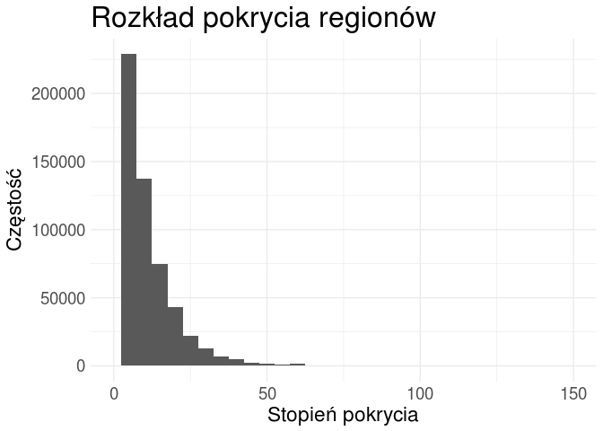

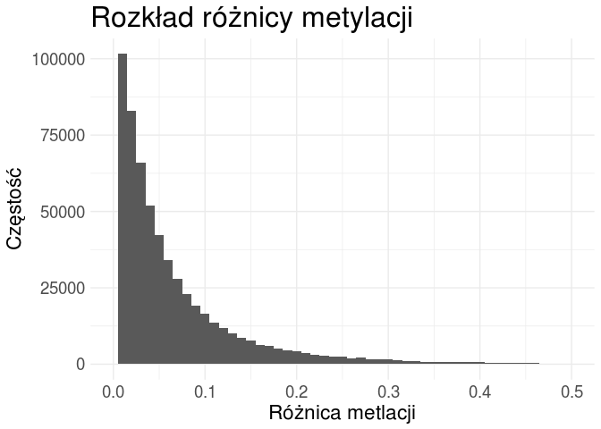

### 2.0.1 tTest:

```
## [1] "Ile braków danych: 54526"
```

|  | pValue | met_max_EK | met_max_EU | met_mean_EK | met_mean_EU | met_min_EK | met_min_EU | met_n_EK | met_n_EU | met_sd_EK | met_sd_EU | met_diff | quantile |
| --- | --- | --- | --- | --- | --- | --- | --- | --- | --- | --- | --- | --- | --- |
| 1 | 4.20648297557299e-26 | 0.8 | 1 | 0.346152728884603 | 0.815553948730039 | 0 | 0.0833333333333333 | 59 | 59 | 0.199134164354862 | 0.197089668802309 | 0.469401219845436 | 0.992765525408412 |
| 2 | 8.14616801878339e-26 | 1 | 0.666666666666667 | 0.763266331624708 | 0.361887820794008 | 0 | 0 | 54 | 54 | 0.205457691596092 | 0.163267078296558 | 0.4013785108307 | 0.991818478072038 |
| 3 | 1.40729209375659e-25 | 0.821428571428571 | 1 | 0.325148179239052 | 0.80046339853569 | 0 | 0 | 59 | 59 | 0.182202926215768 | 0.218853431330803 | 0.475315219296637 | 0.992846160118413 |
| 4 | 2.19995098908097e-25 | 1 | 0.621621621621622 | 0.762454689674781 | 0.330325993779436 | 0 | 0 | 54 | 54 | 0.204374927154892 | 0.142417385247803 | 0.432128695895345 | 0.992238749174809 |
| 5 | 2.33780566219322e-25 | 0.909090909090909 | 1 | 0.346288005046646 | 0.795697012511555 | 0 | 0.0833333333333333 | 59 | 59 | 0.231745152682666 | 0.214791924661014 | 0.449409007464908 | 0.992492940627018 |
| 6 | 3.84836546576968e-25 | 1 | 0.75 | 0.760296124838609 | 0.369891393338789 | 0 | 0 | 54 | 54 | 0.203433697472406 | 0.166045643983573 | 0.39040473149982 | 0.991668496459529 |
| 7 | 6.0080901126058e-25 | 0.793103448275862 | 1 | 0.335781011137013 | 0.803242240657989 | 0 | 0.125 | 59 | 59 | 0.208342527126713 | 0.211234933420973 | 0.467461229520976 | 0.992739074517013 |
| 8 | 6.65073908601018e-25 | 0.818181818181818 | 1 | 0.333125927787718 | 0.804838679054584 | 0 | 0.0416666666666667 | 59 | 59 | 0.197583479487253 | 0.215294976666861 | 0.471712751266866 | 0.99279704209477 |
| 9 | 8.17849532277189e-25 | 0.827586206896552 | 1 | 0.342178768270419 | 0.804030085038145 | 0 | 0.0833333333333333 | 59 | 59 | 0.224618703664681 | 0.21899505072273 | 0.461851316767726 | 0.992662585891724 |
| 10 | 1.30747881222372e-24 | 0.821428571428571 | 1 | 0.336154410785725 | 0.812870655858554 | 0 | 0.0833333333333333 | 59 | 59 | 0.211295158149548 | 0.226087491184715 | 0.476716245072829 | 0.992865262471752 |

[output cut: 90 more lines]

### 2.0.2 Wilcoxon:

```
## [1] "Ile braków danych: 13537"
```

|  | pValue | met_max_EK | met_max_EU | met_mean_EK | met_mean_EU | met_min_EK | met_min_EU | met_n_EK | met_n_EU | met_sd_EK | met_sd_EU | met_diff | quantile |
| --- | --- | --- | --- | --- | --- | --- | --- | --- | --- | --- | --- | --- | --- |
| 1 | 3.60165136680496e-12 | 0.1 | 0.5 | 0.00630963631146404 | 0.192840740933593 | 0 | 0 | 71 | 71 | 0.0188701778993446 | 0.134806129482823 | 0.186531104622129 | 0.968995855097382 |
| 2 | 4.56157548197214e-12 | 0.1 | 0.5625 | 0.00781185520106883 | 0.185774853852806 | 0 | 0 | 71 | 71 | 0.0222974104768238 | 0.143963031744956 | 0.177962998651738 | 0.965657949686757 |
| 3 | 5.52650906282294e-12 | 0.2 | 0.606060606060606 | 0.0109951343824207 | 0.19529929872986 | 0 | 0 | 71 | 71 | 0.0372231520610349 | 0.147004017823592 | 0.18430416434744 | 0.968128298601499 |
| 4 | 5.91536128105289e-12 | 0.1 | 0.5625 | 0.0115593695613396 | 0.182423334990186 | 0 | 0 | 71 | 71 | 0.0268379258599351 | 0.134128688315525 | 0.170863965428846 | 0.962892355810259 |
| 5 | 6.48676911327789e-12 | 0.3 | 0.757575757575758 | 0.0102313034463251 | 0.195273528837807 | 0 | 0 | 71 | 71 | 0.0404882332723001 | 0.156695332542005 | 0.185042225391482 | 0.968415827486038 |
| 6 | 6.94772175185071e-12 | 0.1 | 0.5 | 0.00831850576652693 | 0.187084890558903 | 0 | 0 | 71 | 71 | 0.0214364980906983 | 0.142162089643613 | 0.178766384792376 | 0.965970927485459 |
| 7 | 7.27595761418344e-12 | 0.518518518518518 | 0.88 | 0.177485975769627 | 0.555950740114959 | 0 | 0 | 39 | 39 | 0.144359336571525 | 0.223856297453656 | 0.378464764345332 | 0.991424235335407 |
| 8 | 7.27595761418344e-12 | 0.425925925925926 | 0.94 | 0.164567241330875 | 0.56257967535724 | 0 | 0 | 39 | 39 | 0.129940361348899 | 0.24405174841431 | 0.398012434026364 | 0.991693948467196 |
| 9 | 7.27595761418344e-12 | 0.5 | 0.89 | 0.171119441143806 | 0.556065337478845 | 0 | 0 | 39 | 39 | 0.151375564937458 | 0.227316802607262 | 0.384945896335039 | 0.991513660133094 |
| 10 | 7.27595761418344e-12 | 0.481481481481481 | 0.924242424242424 | 0.171441564917692 | 0.553761857853401 | 0 | 0 | 39 | 39 | 0.140819105836991 | 0.238279579544943 | 0.382320292935709 | 0.991477432811514 |

[output cut: 90 more lines]

### 2.0.3 KStest

```
## [1] "Ile braków danych: 0"
```

|  | type | prob_name | met_max_EK | met_max_EU | met_mean_EK | met_mean_EU | met_min_EK | met_min_EU | met_n_EK | met_n_EU | met_sd_EK | met_sd_EU | met_diff | quantile |
| --- | --- | --- | --- | --- | --- | --- | --- | --- | --- | --- | --- | --- | --- | --- |
| 1 | 0 | 19147_25 | 0.0731707317073171 | 0.0416666666666667 | 0.00426389342116565 | 0.0060870478243529 | 0 | 0 | 41 | 41 | 0.0135042032945893 | 0.0120813603906398 | 0.00182315440318725 | 0.0402378286515845 |
| 2 | 0 | 92463_8 | 0.0666666666666667 | 0.0280373831775701 | 0.00266666666666667 | 0.00227209935016422 | 0 | 0 | 25 | 25 | 0.0133333333333333 | 0.00623481602666753 | 0.000394567316502446 | 0.0137192643477388 |
| 3 | 0 | 37488_15 | 0.0588235294117647 | 0.0446428571428571 | 0.00269152753939772 | 0.00465183137220259 | 0 | 0 | 29 | 29 | 0.0113703009184 | 0.0100634882255067 | 0.00196030383280487 | 0.0464155287006105 |
| 4 | 0 | 32535_28 | 0.0833333333333333 | 0.0333333333333333 | 0.00146198830409357 | 0.00107212475633528 | 0 | 0 | 57 | 57 | 0.0110377696422087 | 0.00569648593789147 | 0.000389863547758285 | 0.0127298173296718 |
| 5 | 0 | 44163_15 | 0.0963855421686747 | 0.111111111111111 | 0.0016290384165844 | 0.00503608985255259 | 0 | 0 | 71 | 71 | 0.0114962096014558 | 0.0194869042622853 | 0.00340705143596819 | 0.122001077060431 |
| 6 | 0 | 6414_18 | 0.0454545454545455 | 0.024390243902439 | 0.00240857555143269 | 0.00354132685669044 | 0 | 0 | 30 | 30 | 0.00897958533540271 | 0.00639942429356702 | 0.00113275130525774 | 0.0279688171957624 |
| 7 | 0 | 45039_3 | 0.0555555555555556 | 0.010752688172043 | 0.00479616036137775 | 0.00146627565982405 | 0 | 0 | 22 | 22 | 0.013050875347204 | 0.00377688265222693 | 0.0033298847015537 | 0.0957126276734949 |
| 8 | 0 | 124405_9 | 0.238095238095238 | 0.0857142857142857 | 0.00672268355987638 | 0.00731229271642024 | 0 | 0 | 69 | 69 | 0.0350384665197236 | 0.017049431061751 | 0.00058960915654386 | 0.0161628512136943 |
| 9 | 0 | 112430_29 | 0.0246913580246914 | 0.0461538461538462 | 0.00114843525696239 | 0.00355601563710327 | 0 | 0 | 43 | 43 | 0.00526129956336904 | 0.00952358140992965 | 0.00240758038014088 | 0.0627081767387025 |
| 10 | 0 | 92463_13 | 0.0666666666666667 | 0.0192307692307692 | 0.00266666666666667 | 0.0026709559452825 | 0 | 0 | 25 | 25 | 0.0133333333333333 | 0.00645425087468976 | 4.289278615832e-06 | 0.000200221651531032 |

[output cut: 90 more lines]

### 2.0.4 Regresja logistyczna:

```
## [1] "Ile braków danych: 48950"
```

Szeregowanie po pValue:

|  | pValue | beta | met_max_EK | met_max_EU | met_mean_EK | met_mean_EU | met_min_EK | met_min_EU | met_n_EK | met_n_EU | met_sd_EK | met_sd_EU | met_diff | quantile |
| --- | --- | --- | --- | --- | --- | --- | --- | --- | --- | --- | --- | --- | --- | --- |
| 1 | 9.92856068028448e-160 | -2.85037952688348 | 0.901869158878505 | 0.303571428571429 | 0.65908168032294 | 0.158704505279793 | 0.0327102803738318 | 0.00706713780918728 | 6 | 6 | 0.315936881731394 | 0.11503576694765 | 0.500377175043147 | 0.992503426502582 |
| 2 | 2.10330531467177e-158 | 3.48849894344952 | 1 | 1 | 0.314681399983439 | 0.886443205890897 | 0 | 0.0277777777777778 | 29 | 29 | 0.186283467418972 | 0.214419975277334 | 0.571761805907458 | 0.994033797281397 |
| 3 | 1.78151560572683e-157 | 3.60178975030446 | 1 | 1 | 0.326694643399201 | 0.889955831568669 | 0 | 0.0277777777777778 | 29 | 29 | 0.185601388341322 | 0.210813400391165 | 0.563261188169468 | 0.993915366909334 |
| 4 | 3.97640457564785e-157 | -2.79620702883415 | 0.864485981308411 | 0.296428571428571 | 0.653069404844881 | 0.159318879907618 | 0.0186915887850467 | 0.0106007067137809 | 6 | 6 | 0.316576640247868 | 0.111259769078071 | 0.493750524937263 | 0.992403997158928 |
| 5 | 5.8264120774367e-157 | 3.40243904139161 | 1 | 1 | 0.311336344779997 | 0.877139598499259 | 0 | 0.0555555555555556 | 29 | 29 | 0.174882034486963 | 0.222927594319279 | 0.565803253719263 | 0.993950782896519 |
| 6 | 7.33074377463668e-157 | 3.46637238617744 | 1 | 1 | 0.325820541627613 | 0.882896873400686 | 0 | 0.0555555555555556 | 29 | 29 | 0.200348642569307 | 0.207804974646232 | 0.557076331773073 | 0.993829199660463 |
| 7 | 2.45587188135965e-156 | 3.41983709207127 | 1 | 1 | 0.324507731933383 | 0.884104342567885 | 0 | 0.0277777777777778 | 29 | 29 | 0.183554223597648 | 0.208463509297671 | 0.559596610634502 | 0.993864312116106 |
| 8 | 3.91206147639637e-156 | 3.45198987540407 | 1 | 1 | 0.328796040423022 | 0.884111072739275 | 0 | 0.0277777777777778 | 29 | 29 | 0.186665342390021 | 0.212269868326118 | 0.555315032316253 | 0.993804661284969 |
| 9 | 4.01228402441579e-156 | -2.81528988974174 | 0.873831775700935 | 0.328571428571429 | 0.669401543678125 | 0.175523954295469 | 0.0186915887850467 | 0.00353356890459364 | 6 | 6 | 0.323211525917917 | 0.126580806591932 | 0.493877589382656 | 0.992405903693029 |
| 10 | 7.04509060042339e-155 | 3.36809755236936 | 1 | 1 | 0.326838101612375 | 0.873868013481012 | 0 | 0 | 29 | 29 | 0.204336854215125 | 0.220960947394587 | 0.547029911868636 | 0.993689233215216 |

[output cut: 90 more lines]

Szeregowane po beta:

|  | pValue | beta | met_max_EK | met_max_EU | met_mean_EK | met_mean_EU | met_min_EK | met_min_EU | met_n_EK | met_n_EU | met_sd_EK | met_sd_EU | met_diff | quantile |
| --- | --- | --- | --- | --- | --- | --- | --- | --- | --- | --- | --- | --- | --- | --- |
| 1 | 7.89635045404912e-07 | 5.01505045600691 | 0.04 | 0.565217391304348 | 0.00444444444444444 | 0.371520588911893 | 0 | 0 | 9 | 9 | 0.0133333333333333 | 0.168222204504192 | 0.367076144467449 | 0.990724268149108 |
| 2 | 1.01449036359653e-05 | 4.98619505982492 | 0.0833333333333333 | 0.857142857142857 | 0.0208333333333333 | 0.676190476190476 | 0 | 0.533333333333333 | 4 | 4 | 0.0416666666666667 | 0.141901565959537 | 0.655357142857143 | 0.994683859486236 |
| 3 | 1.30628140343273e-06 | 4.91424355511657 | 0.04 | 0.521739130434783 | 0.00444444444444444 | 0.348976305498045 | 0 | 0 | 9 | 9 | 0.0133333333333333 | 0.167363200947565 | 0.3445318610536 | 0.990393873385362 |
| 4 | 0.000111599140146729 | 4.90502136846609 | 0.0909090909090909 | 0.952380952380952 | 0.0454545454545455 | 0.501190476190476 | 0 | 0.05 | 2 | 2 | 0.0642824346533225 | 0.638079690642146 | 0.455735930735931 | 0.991091237291727 |
| 5 | 3.05401339642931e-06 | 4.90397366184322 | 0.0625 | 0.861111111111111 | 0.03125 | 0.776709401709402 | 0 | 0.692307692307692 | 2 | 2 | 0.0441941738241592 | 0.11936204212337 | 0.745459401709402 | 0.995833563305292 |
| 6 | 0.000118057927055161 | 4.89734634419799 | 0.0909090909090909 | 0.952380952380952 | 0.0454545454545455 | 0.476190476190476 | 0 | 0 | 2 | 2 | 0.0642824346533225 | 0.673435029701474 | 0.430735930735931 | 0.990682025880788 |
| 7 | 0.000124336066560577 | 4.89034912822175 | 0.0666666666666667 | 0.904761904761905 | 0.0333333333333333 | 0.452380952380952 | 0 | 0 | 2 | 2 | 0.0471404520791032 | 0.6397632782164 | 0.419047619047619 | 0.99049070626009 |
| 8 | 1.57827489865378e-06 | 4.87898135343882 | 0.04 | 0.523809523809524 | 0.00444444444444444 | 0.341614906832298 | 0 | 0 | 9 | 9 | 0.0133333333333333 | 0.157747807869433 | 0.337170462387854 | 0.990285989380874 |
| 9 | 0.000128689195231371 | 4.87470397440257 | 0.0909090909090909 | 1 | 0.0787878787878788 | 0.5 | 0.0666666666666667 | 0 | 2 | 2 | 0.0171419825742193 | 0.707106781186548 | 0.421212121212121 | 0.990526135819478 |
| 10 | 0.000128689220229243 | 4.87470397440256 | 0.133333333333333 | 0.952380952380952 | 0.0666666666666667 | 0.501190476190476 | 0 | 0.05 | 2 | 2 | 0.0942809041582063 | 0.638079690642146 | 0.43452380952381 | 0.990744027609718 |

[output cut: 90 more lines]

### 2.0.5 Regresja logistyczna z efektami losowymi:

```
## [1] "Ile braków danych: 52944"
```

Szeregowanie po pValue:

|  | pValue | beta | met_max_EK | met_max_EU | met_mean_EK | met_mean_EU | met_min_EK | met_min_EU | met_n_EK | met_n_EU | met_sd_EK | met_sd_EU | met_diff | quantile |
| --- | --- | --- | --- | --- | --- | --- | --- | --- | --- | --- | --- | --- | --- | --- |
| 1 | 0 | 0.799733452446504 | 0.5 | 0.692307692307692 | 0.25 | 0.346153846153846 | 0 | 0 | 2 | 2 | 0.353553390593274 | 0.489535463898379 | 0.0961538461538461 | 0.756489468175116 |
| 2 | 0 | -1.23757208204321 | 0.91304347826087 | 0.944444444444444 | 0.575252709779564 | 0.398078529657477 | 0 | 0 | 7 | 7 | 0.399600730096321 | 0.334640696399995 | 0.177174180122087 | 0.939827925080952 |
| 3 | 0 | 0.161152064067769 | 1 | 1 | 0.789959247712778 | 0.827847144803667 | 0.0526315789473684 | 0.107142857142857 | 10 | 10 | 0.337811252208571 | 0.291580450258865 | 0.0378878970908886 | 0.603634456842971 |
| 4 | 0 | 1.88922714830996 | 0.222222222222222 | 0.615384615384615 | 0.122222222222222 | 0.416410256410256 | 0 | 0 | 5 | 5 | 0.113855008510662 | 0.258489009529104 | 0.294188034188034 | 0.981265820611079 |
| 5 | 0 | 0.102681598501856 | 1 | 1 | 0.849583333333333 | 0.853154761904762 | 0 | 0.133333333333333 | 10 | 10 | 0.320195072197027 | 0.270092677292974 | 0.00357142857142856 | 0.0925194950845115 |
| 6 | 0 | -0.138401577361945 | 1 | 1 | 0.845723684210526 | 0.838707359741703 | 0 | 0.0625 | 8 | 8 | 0.344218279269335 | 0.316464002189353 | 0.00701632446882294 | 0.160610014953723 |
| 7 | 0 | -2.68177160711214 | 1 | 1 | 0.562083279764738 | 0.161380729388392 | 0 | 0 | 27 | 27 | 0.254437278070703 | 0.275876702227276 | 0.400702550376346 | 0.991629725725235 |
| 8 | 0 | 0.222023593238799 | 0.214285714285714 | 0.477272727272727 | 0.0854139808763585 | 0.106352823275471 | 0 | 0 | 20 | 20 | 0.0702886104670669 | 0.11932948169108 | 0.0209388423991127 | 0.471210567582282 |
| 9 | 0 | 0.741283881498146 | 1 | 1 | 0.80116027030473 | 0.827389309259298 | 0 | 0 | 13 | 13 | 0.361632495219048 | 0.357609945468809 | 0.0262290389545672 | 0.505153815722817 |
| 10 | 0 | -1.17216887375282 | 0.62962962962963 | 0.260869565217391 | 0.111851851851852 | 0.046972049689441 | 0 | 0 | 16 | 16 | 0.188060638733569 | 0.081046381012104 | 0.0648798021624109 | 0.792844728243924 |

[output cut: 90 more lines]

Szeregowane po beta:

|  | pValue | beta | met_max_EK | met_max_EU | met_mean_EK | met_mean_EU | met_min_EK | met_min_EU | met_n_EK | met_n_EU | met_sd_EK | met_sd_EU | met_diff | quantile |
| --- | --- | --- | --- | --- | --- | --- | --- | --- | --- | --- | --- | --- | --- | --- |
| 1 | 0 | 29.887620394465 | 0 | 0.0689655172413793 | 0 | 0.0172413793103448 | 0 | 0 | 4 | 4 | 0 | 0.0344827586206897 | 0.0172413793103448 | 0.289876411451567 |
| 2 | 0 | 29.887620394465 | 0 | 0.0689655172413793 | 0 | 0.0172413793103448 | 0 | 0 | 4 | 4 | 0 | 0.0344827586206897 | 0.0172413793103448 | 0.289876411451567 |
| 3 | 0 | 29.887620394465 | 0 | 0.0689655172413793 | 0 | 0.0172413793103448 | 0 | 0 | 4 | 4 | 0 | 0.0344827586206897 | 0.0172413793103448 | 0.289876411451567 |
| 4 | 0 | 29.887620394465 | 0 | 0.0689655172413793 | 0 | 0.0172413793103448 | 0 | 0 | 4 | 4 | 0 | 0.0344827586206897 | 0.0172413793103448 | 0.289876411451567 |
| 5 | 0 | 29.887620394465 | 0 | 0.0689655172413793 | 0 | 0.0172413793103448 | 0 | 0 | 4 | 4 | 0 | 0.0344827586206897 | 0.0172413793103448 | 0.289876411451567 |
| 6 | 0 | 29.887620394465 | 0 | 0.0689655172413793 | 0 | 0.0172413793103448 | 0 | 0 | 4 | 4 | 0 | 0.0344827586206897 | 0.0172413793103448 | 0.289876411451567 |
| 7 | 0 | 29.5936058886718 | 0 | 0.075 | 0 | 0.0062900641025641 | 0 | 0 | 16 | 16 | 0 | 0.0194069123309091 | 0.0062900641025641 | 0.169254903044471 |
| 8 | 0 | 29.5936058886718 | 0 | 0.075 | 0 | 0.0062900641025641 | 0 | 0 | 16 | 16 | 0 | 0.0194069123309091 | 0.0062900641025641 | 0.169254903044471 |
| 9 | 0 | 29.5802935830236 | 0 | 0.111111111111111 | 0 | 0.00576338555061959 | 0 | 0 | 47 | 47 | 0 | 0.0188710892316353 | 0.00576338555061959 | 0.197131392528522 |
| 10 | 0 | 28.6339989872732 | 0 | 0.0769230769230769 | 0 | 0.0186080586080586 | 0 | 0 | 7 | 7 | 0 | 0.0325007315087713 | 0.0186080586080586 | 0.350013555811205 |

[output cut: 90 more lines]

### 2.0.6 Regresja logistyczna z efektami losowymi z uwzgl?dnieniem korelacji:

```
## [1] "Ile braków danych: 51417"
```

Szeregowanie po pValue:

|  | pValue | beta | met_max_EK | met_max_EU | met_mean_EK | met_mean_EU | met_min_EK | met_min_EU | met_n_EK | met_n_EU | met_sd_EK | met_sd_EU | met_diff | quantile |
| --- | --- | --- | --- | --- | --- | --- | --- | --- | --- | --- | --- | --- | --- | --- |
| 1 | 1.56048337331869e-66 | -16.5267514925551 | 0.125 | 0.125 | 0.00419442785189118 | 0.00182622504537205 | 0 | 0 | 95 | 95 | 0.0184276212340595 | 0.0132817237083362 | 0.00236820280651913 | 0.0536348058857232 |
| 2 | 2.05145737239226e-33 | -8.01480542915014 | 0.2 | 0.151515151515152 | 0.018475713811465 | 0.00330094960967444 | 0 | 0 | 52 | 52 | 0.0418296420898739 | 0.0211417356636485 | 0.0151747642017906 | 0.444126370547408 |
| 3 | 3.14452168396823e-30 | -5.87689814118413 | 0.0740740740740741 | 0.0833333333333333 | 0.00555398618957941 | 0.00243965074473549 | 0 | 0 | 59 | 59 | 0.0160217986174073 | 0.013304379093061 | 0.00311433544484392 | 0.102754044981773 |
| 4 | 1.55334144011188e-29 | -5.80386420116584 | 0.183673469387755 | 0.177777777777778 | 0.0107372497881643 | 0.00841102961485998 | 0 | 0 | 51 | 51 | 0.0320323673793171 | 0.027884992987046 | 0.00232622017330429 | 0.0566843665807246 |
| 5 | 1.9825676214969e-29 | -18.4837740535683 | 0.0307692307692308 | 0.0461538461538462 | 0.00233284259600049 | 0.00293680984539565 | 0 | 0 | 38 | 38 | 0.00713961355828978 | 0.00948415291660607 | 0.000603967249395158 | 0.0172479649809271 |
| 6 | 1.01873006496875e-26 | -9.79923142252484 | 0.0606060606060606 | 0.0909090909090909 | 0.00352913906208128 | 0.00461807221912945 | 0 | 0 | 44 | 44 | 0.0129136790989525 | 0.0163375246570216 | 0.00108893315704818 | 0.0259888853139481 |
| 7 | 2.82110397621986e-24 | -2.70368101301471 | 0.12 | 0.125 | 0.00354985140446745 | 0.00167876588021779 | 0 | 0 | 95 | 95 | 0.0168320394449661 | 0.0130268936661533 | 0.00187108552424967 | 0.037815385624378 |
| 8 | 2.94337498314249e-24 | -6.56975951282872 | 0.0273972602739726 | 0.0277777777777778 | 0.00101826484018265 | 0.00234424981302769 | 0 | 0 | 40 | 40 | 0.00476879040973567 | 0.00724676430710077 | 0.00132598497284504 | 0.0306663666804033 |
| 9 | 1.684034289596e-22 | -2.12829661986188 | 0.125 | 0.0344827586206897 | 0.00289618223785609 | 0.000691923774954628 | 0 | 0 | 95 | 95 | 0.0144965245011299 | 0.00474917807402786 | 0.00220425846290147 | 0.0461935396688568 |
| 10 | 5.48324772597137e-21 | -3.6792445865097 | 0.16144578313253 | 0.0790123456790123 | 0.00322098311039516 | 0.00322384583822697 | 0 | 0 | 71 | 71 | 0.0194841631142136 | 0.0123216862110395 | 2.86272783181062e-06 | 0.00011592558354801 |

[output cut: 90 more lines]

Szeregowane po beta:

|  | pValue | beta | met_max_EK | met_max_EU | met_mean_EK | met_mean_EU | met_min_EK | met_min_EU | met_n_EK | met_n_EU | met_sd_EK | met_sd_EU | met_diff | quantile |
| --- | --- | --- | --- | --- | --- | --- | --- | --- | --- | --- | --- | --- | --- | --- |
| 1 | 0.000113094971058024 | 26.4422679343005 | 0.909090909090909 | 1 | 0.849282296650718 | 0.993827160493827 | 0.789473684210526 | 0.987654320987654 | 2 | 2 | 0.0845821508596348 | 0.00872971334798211 | 0.144544863843109 | 0.861030106928044 |
| 2 | 1.2734475342662e-05 | 24.0869348199827 | 1 | 1 | 0.88 | 0.798830409356725 | 0.4 | 0.105263157894737 | 5 | 5 | 0.268328157299975 | 0.390689670529863 | 0.0811695906432749 | 0.777793461174173 |
| 3 | 9.92352793698746e-05 | 19.5098712437866 | 1 | 1 | 0.964285714285714 | 0.97140522875817 | 0.857142857142857 | 0.941176470588235 | 4 | 4 | 0.0714285714285714 | 0.0240331279661331 | 0.00711951447245562 | 0.141476977938939 |
| 4 | 3.57106208841282e-07 | 18.9410325108647 | 1 | 1 | 0.807261366084896 | 0.834802523550255 | 0.0769230769230769 | 0 | 7 | 7 | 0.325953542878056 | 0.368492834163941 | 0.0275411574653595 | 0.465882835035968 |
| 5 | 3.77317983242362e-07 | 17.853725992406 | 1 | 1 | 0.777013130833729 | 0.823694440773534 | 0.0476190476190476 | 0 | 7 | 7 | 0.331057486729405 | 0.365116763006168 | 0.0466813099398055 | 0.639296284042177 |
| 6 | 0.000763070080458301 | 16.7923338094595 | 0 | 0.0263157894736842 | 0 | 0.0131578947368421 | 0 | 0 | 2 | 2 | 0 | 0.0186080731891197 | 0.0131578947368421 | 0.19858952876356 |
| 7 | 0.000763070080458301 | 16.7923338094595 | 0 | 0.0263157894736842 | 0 | 0.0131578947368421 | 0 | 0 | 2 | 2 | 0 | 0.0186080731891197 | 0.0131578947368421 | 0.19858952876356 |
| 8 | 0.000928339743027641 | 15.7040605777807 | 1 | 1 | 0.738461538461539 | 0.822222222222222 | 0 | 0.222222222222222 | 5 | 5 | 0.419918278890959 | 0.33655847179691 | 0.0837606837606837 | 0.786011379290748 |
| 9 | 5.91255263785023e-06 | 15.4759928541916 | 1 | 1 | 0.865242284597123 | 0.861751152073733 | 0.151515151515152 | 0.129032258064516 | 7 | 7 | 0.315671149994999 | 0.325105327639765 | 0.00349113252339051 | 0.0871971790697015 |
| 10 | 1.95609341816741e-08 | 15.4468151919222 | 1 | 1 | 0.833333333333333 | 0.843652174222374 | 0 | 0 | 8 | 8 | 0.345492517089849 | 0.342685025813963 | 0.0103188408890407 | 0.223218247747282 |

[output cut: 90 more lines]

### 2.0.7 Podsumowanie:

#### 2.0.7.1 Diagramy Venna:

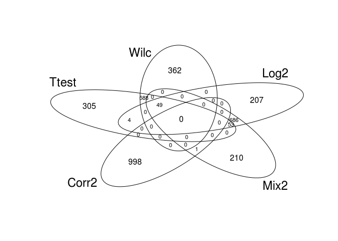

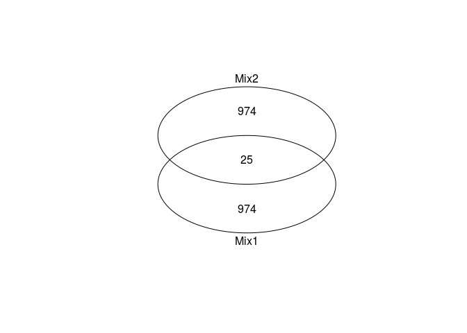

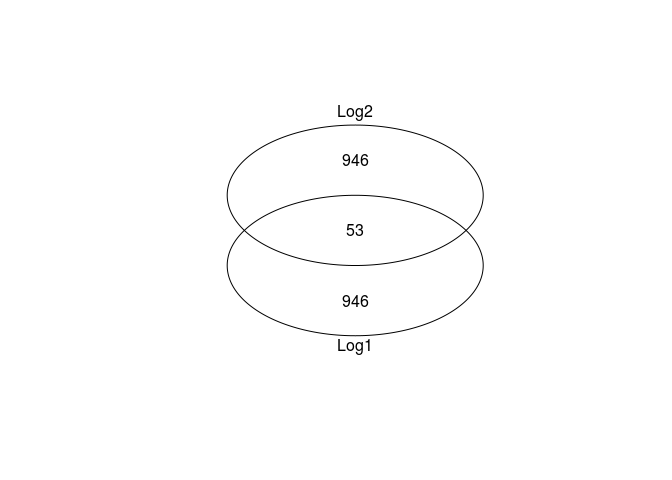

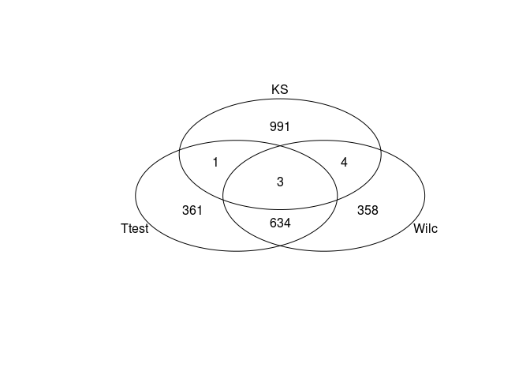

### 2.0.8 Rozkłady top 1000 każdej z metod

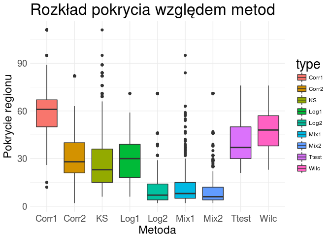

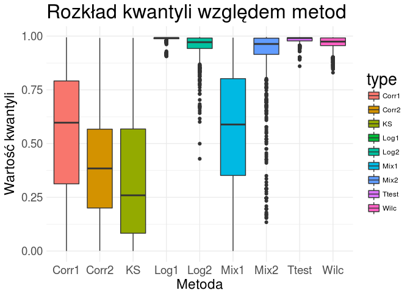

# 3 Metoda 2.

## 3.1 p = 0.02

```
## [1] "Ilosc regionów: 392280"
```

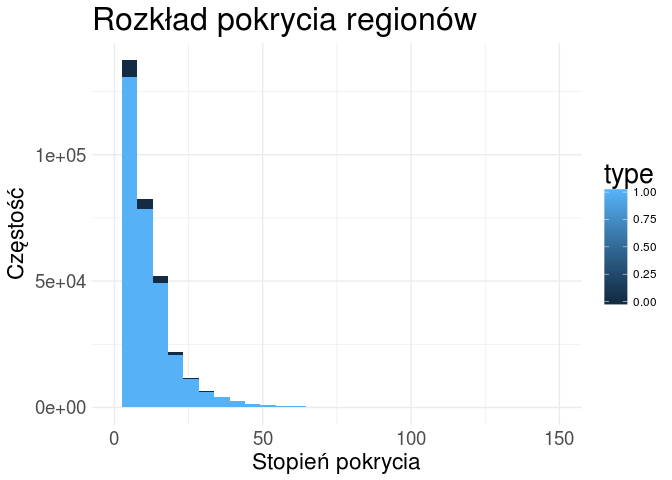

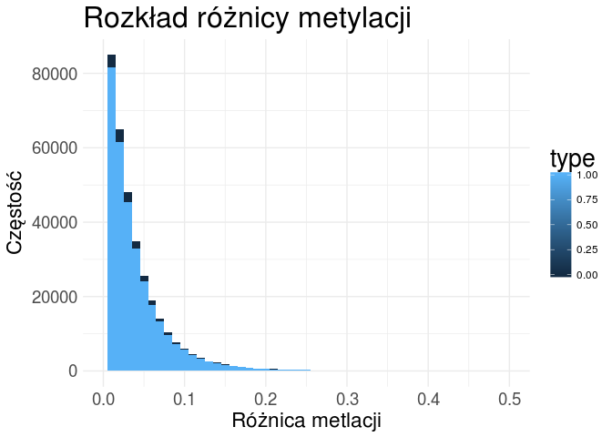

### 3.1.1 tTest:

```
## [1] "Ile brak?w danych: 31487"
```

|  | type | prob_name | met_max_EK | met_max_EU | met_mean_EK | met_mean_EU | met_min_EK | met_min_EU | met_n_EK | met_n_EU | met_sd_EK | met_sd_EU | met_diff | quantile |
| --- | --- | --- | --- | --- | --- | --- | --- | --- | --- | --- | --- | --- | --- | --- |
| 1 | 0 | 19147_25 | 0.0294117647058824 | 0.0645161290322581 | 0.00371168085186352 | 0.0259556070807713 | 0 | 0 | 41 | 41 | 0.00878513673352308 | 0.0147096889805819 | 0.0222439262289078 | 0.55137747479988 |
| 2 | 0 | 32535_28 | 0.037037037037037 | 0.107142857142857 | 0.00194931773879142 | 0.0279433057252352 | 0 | 0 | 57 | 57 | 0.00834376957202932 | 0.0248937510778754 | 0.0259939879864438 | 0.630488699848799 |
| 3 | 0 | 112430_29 | 0.0256410256410256 | 0.0483870967741935 | 0.00346714142910285 | 0.0205211501537826 | 0 | 0 | 43 | 43 | 0.00731775449933732 | 0.013427588031813 | 0.0170540087246798 | 0.469275097808799 |
| 4 | 0 | 124405_9 | 0.0526315789473684 | 0.08 | 0.00633291157633292 | 0.0252138975600688 | 0 | 0 | 69 | 69 | 0.0143650348811566 | 0.0206488857963906 | 0.0188809859837359 | 0.540696099635735 |
| 5 | 0 | 37488_15 | 0.0196078431372549 | 0.0588235294117647 | 0.000676132521974307 | 0.0247032224200244 | 0 | 0 | 29 | 29 | 0.00364108506229513 | 0.0137539291165141 | 0.0240270898980501 | 0.547522421871023 |
| 6 | 0 | 44163_15 | 0.0476190476190476 | 0.16 | 0.0023891009845884 | 0.0323164779774628 | 0 | 0 | 71 | 71 | 0.00828470178127573 | 0.0360467865418158 | 0.0299273769928744 | 0.685343871743437 |
| 7 | 0 | 92463_13 | 0.0196078431372549 | 0.0576923076923077 | 0.000784313725490196 | 0.0279381161040343 | 0 | 0 | 25 | 25 | 0.00392156862745098 | 0.0164083421133382 | 0.0271538023785441 | 0.576063397258507 |
| 8 | 0 | 44163_19 | 0.0476190476190476 | 0.142857142857143 | 0.00261966820378819 | 0.0289791670817015 | 0 | 0 | 71 | 71 | 0.0091362091770504 | 0.0322581955569909 | 0.0263594988779133 | 0.649164051937043 |
| 9 | 0 | 45026_14 | 0.0454545454545455 | 0.0666666666666667 | 0.00113636363636364 | 0.0243094557905132 | 0 | 0 | 40 | 40 | 0.00718699468220087 | 0.0208842054209798 | 0.0231730921541495 | 0.563430897703831 |
| 10 | 0 | 107643_27 | 0.0425531914893617 | 0.0652173913043478 | 0.00716002422014134 | 0.0274855871136808 | 0 | 0 | 48 | 48 | 0.0126413927248131 | 0.0187429737303515 | 0.0203255628935395 | 0.534109836432273 |

[output cut: 90 more lines]

### 3.1.2 Wilcoxon:

```
## [1] "Ile braków danych: 5390"
```

|  | type | prob_name | met_max_EK | met_max_EU | met_mean_EK | met_mean_EU | met_min_EK | met_min_EU | met_n_EK | met_n_EU | met_sd_EK | met_sd_EU | met_diff | quantile |
| --- | --- | --- | --- | --- | --- | --- | --- | --- | --- | --- | --- | --- | --- | --- |
| 1 | 0 | 44163_15 | 0.0476190476190476 | 0.16 | 0.0023891009845884 | 0.0323164779774628 | 0 | 0 | 71 | 71 | 0.00828470178127573 | 0.0360467865418158 | 0.0299273769928744 | 0.685343871743437 |
| 2 | 0 | 44163_19 | 0.0476190476190476 | 0.142857142857143 | 0.00261966820378819 | 0.0289791670817015 | 0 | 0 | 71 | 71 | 0.0091362091770504 | 0.0322581955569909 | 0.0263594988779133 | 0.649164051937043 |
| 3 | 0 | 19147_25 | 0.0294117647058824 | 0.0645161290322581 | 0.00371168085186352 | 0.0259556070807713 | 0 | 0 | 41 | 41 | 0.00878513673352308 | 0.0147096889805819 | 0.0222439262289078 | 0.55137747479988 |
| 4 | 0 | 112430_29 | 0.0256410256410256 | 0.0483870967741935 | 0.00346714142910285 | 0.0205211501537826 | 0 | 0 | 43 | 43 | 0.00731775449933732 | 0.013427588031813 | 0.0170540087246798 | 0.469275097808799 |
| 5 | 0 | 124405_9 | 0.0526315789473684 | 0.08 | 0.00633291157633292 | 0.0252138975600688 | 0 | 0 | 69 | 69 | 0.0143650348811566 | 0.0206488857963906 | 0.0188809859837359 | 0.540696099635735 |
| 6 | 0 | 32535_28 | 0.037037037037037 | 0.107142857142857 | 0.00194931773879142 | 0.0279433057252352 | 0 | 0 | 57 | 57 | 0.00834376957202932 | 0.0248937510778754 | 0.0259939879864438 | 0.630488699848799 |
| 7 | 0 | 107643_27 | 0.0425531914893617 | 0.0652173913043478 | 0.00716002422014134 | 0.0274855871136808 | 0 | 0 | 48 | 48 | 0.0126413927248131 | 0.0187429737303515 | 0.0203255628935395 | 0.534109836432273 |
| 8 | 0 | 64601_26 | 0.0115606936416185 | 0.272727272727273 | 0.000872739192955347 | 0.0269869530888699 | 0 | 0 | 54 | 54 | 0.0022707383563339 | 0.0493830160081976 | 0.0261142138959145 | 0.627025388611175 |
| 9 | 0 | 126893_4 | 0.0714285714285714 | 0.08 | 0.00117096018735363 | 0.0237893250192084 | 0 | 0 | 61 | 61 | 0.00914549142377829 | 0.0264730620138581 | 0.0226183648318547 | 0.590346339567852 |
| 10 | 0 | 64601_4 | 0.00578034682080925 | 0.1 | 0.000671683485274394 | 0.0196145549626013 | 0 | 0 | 54 | 54 | 0.00175927122019156 | 0.0266637765304098 | 0.0189428714773269 | 0.519615131069199 |

[output cut: 90 more lines]

### 3.1.3 KSTest:

```
## [1] "Ile braków danych: 0"
```

|  | type | prob_name | met_max_EK | met_max_EU | met_mean_EK | met_mean_EU | met_min_EK | met_min_EU | met_n_EK | met_n_EU | met_sd_EK | met_sd_EU | met_diff | quantile |
| --- | --- | --- | --- | --- | --- | --- | --- | --- | --- | --- | --- | --- | --- | --- |
| 1 | 0 | 19147_25 | 0.0294117647058824 | 0.0645161290322581 | 0.00371168085186352 | 0.0259556070807713 | 0 | 0 | 41 | 41 | 0.00878513673352308 | 0.0147096889805819 | 0.0222439262289078 | 0.55137747479988 |
| 2 | 0 | 92463_8 | 0 | 0.06 | 0 | 0.0239348439210708 | 0 | 0 | 25 | 25 | 0 | 0.0159942391650539 | 0.0239348439210708 | 0.532754893583763 |
| 3 | 0 | 37488_15 | 0.0196078431372549 | 0.0588235294117647 | 0.000676132521974307 | 0.0247032224200244 | 0 | 0 | 29 | 29 | 0.00364108506229513 | 0.0137539291165141 | 0.0240270898980501 | 0.547522421871023 |
| 4 | 0 | 32535_28 | 0.037037037037037 | 0.107142857142857 | 0.00194931773879142 | 0.0279433057252352 | 0 | 0 | 57 | 57 | 0.00834376957202932 | 0.0248937510778754 | 0.0259939879864438 | 0.630488699848799 |
| 5 | 0 | 44163_15 | 0.0476190476190476 | 0.16 | 0.0023891009845884 | 0.0323164779774628 | 0 | 0 | 71 | 71 | 0.00828470178127573 | 0.0360467865418158 | 0.0299273769928744 | 0.685343871743437 |
| 6 | 0 | 6414_18 | 0.0204081632653061 | 0.1 | 0.00179306290417402 | 0.0241535649620266 | 0 | 0 | 30 | 30 | 0.00432814723007425 | 0.0226360765618699 | 0.0223605020578526 | 0.525551379967973 |
| 7 | 0 | 45039_3 | 0.00840336134453781 | 0.0648148148148148 | 0.00110635769459299 | 0.0240333059888344 | 0 | 0 | 22 | 22 | 0.00285086485164008 | 0.016189510499788 | 0.0229269482942414 | 0.50704181719509 |
| 8 | 0 | 124405_9 | 0.0526315789473684 | 0.08 | 0.00633291157633292 | 0.0252138975600688 | 0 | 0 | 69 | 69 | 0.0143650348811566 | 0.0206488857963906 | 0.0188809859837359 | 0.540696099635735 |
| 9 | 0 | 112430_29 | 0.0256410256410256 | 0.0483870967741935 | 0.00346714142910285 | 0.0205211501537826 | 0 | 0 | 43 | 43 | 0.00731775449933732 | 0.013427588031813 | 0.0170540087246798 | 0.469275097808799 |
| 10 | 0 | 92463_13 | 0.0196078431372549 | 0.0576923076923077 | 0.000784313725490196 | 0.0279381161040343 | 0 | 0 | 25 | 25 | 0.00392156862745098 | 0.0164083421133382 | 0.0271538023785441 | 0.576063397258507 |

[output cut: 90 more lines]

### 3.1.4 Regresja logistyczna:

```
## [1] "Ile braków danych: 29370"
```

Szeregowanie po pValue:

|  | type | pValue | prob_name | met_max_EK | met_max_EU | met_mean_EK | met_mean_EU | met_min_EK | met_min_EU | met_n_EK | met_n_EU | met_sd_EK | met_sd_EU | met_diff | quantile |
| --- | --- | --- | --- | --- | --- | --- | --- | --- | --- | --- | --- | --- | --- | --- | --- |
| 1 | 0 | 6.58207210456001e-15 | 64601_26 | 0.0115606936416185 | 0.272727272727273 | 0.000872739192955347 | 0.0269869530888699 | 0 | 0 | 54 | 54 | 0.0022707383563339 | 0.0493830160081976 | 0.0261142138959145 | 0.627025388611175 |
| 2 | 0 | 1.39725744926011e-14 | 44163_19 | 0.0476190476190476 | 0.142857142857143 | 0.00261966820378819 | 0.0289791670817015 | 0 | 0 | 71 | 71 | 0.0091362091770504 | 0.0322581955569909 | 0.0263594988779133 | 0.649164051937043 |
| 3 | 0 | 1.84142242853474e-14 | 44163_15 | 0.0476190476190476 | 0.16 | 0.0023891009845884 | 0.0323164779774628 | 0 | 0 | 71 | 71 | 0.00828470178127573 | 0.0360467865418158 | 0.0299273769928744 | 0.685343871743437 |
| 4 | 0 | 1.33507471223835e-13 | 64601_4 | 0.00578034682080925 | 0.1 | 0.000671683485274394 | 0.0196145549626013 | 0 | 0 | 54 | 54 | 0.00175927122019156 | 0.0266637765304098 | 0.0189428714773269 | 0.519615131069199 |
| 5 | 0 | 1.09957667226908e-12 | 64601_6 | 0.0118343195266272 | 0.1 | 0.000780340452034456 | 0.0167592417288539 | 0 | 0 | 54 | 54 | 0.00221585256030016 | 0.0259017919166999 | 0.0159789012768194 | 0.46520247542285 |
| 6 | 0 | 3.75679016740503e-12 | 64601_22 | 0.0833333333333333 | 0.2 | 0.00324829968642659 | 0.0258164943909755 | 0 | 0 | 54 | 54 | 0.0152762934909164 | 0.0387467303520366 | 0.0225681947045489 | 0.580770401299067 |
| 7 | 0 | 1.70628825974405e-11 | 44163_28 | 0.0476190476190476 | 0.157894736842105 | 0.00199157873833901 | 0.0203798511178441 | 0 | 0 | 71 | 71 | 0.0086416944419709 | 0.0312946939660392 | 0.018388272379505 | 0.532261758074181 |
| 8 | 0 | 1.61042719331747e-09 | 74071_24 | 0.0555555555555556 | 0.0666666666666667 | 0.00404357230085633 | 0.023812105739635 | 0 | 0 | 25 | 25 | 0.0110621492676806 | 0.0194370999703941 | 0.0197685334387787 | 0.471830739019386 |
| 9 | 0 | 3.82880493601178e-09 | 100472_20 | 0.0909090909090909 | 0.307692307692308 | 0.0241469201046217 | 0.0651311629503424 | 0 | 0 | 65 | 65 | 0.0312867902619338 | 0.0540986325328352 | 0.0409842428457207 | 0.755122272242966 |
| 10 | 0 | 5.63509411307421e-09 | 5461_7 | 0.0125786163522013 | 0.0642857142857143 | 0.00461197546515147 | 0.0262447821309948 | 0 | 0.0111731843575419 | 17 | 17 | 0.005015748155999 | 0.0122938572156273 | 0.0216328066658433 | 0.467179198189706 |

[output cut: 90 more lines]

Szeregowane po beta:

|  | type | pValue | prob_name | met_max_EK | met_max_EU | met_mean_EK | met_mean_EU | met_min_EK | met_min_EU | met_n_EK | met_n_EU | met_sd_EK | met_sd_EU | met_diff | quantile |
| --- | --- | --- | --- | --- | --- | --- | --- | --- | --- | --- | --- | --- | --- | --- | --- |
| 1 | 0 | 0.000167003287989527 | 6121_9 | 0.037037037037037 | 0.0769230769230769 | 0.000740740740740741 | 0.023541664655626 | 0 | 0 | 50 | 50 | 0.00523782800878924 | 0.0249707803161609 | 0.0228009239148852 | 0.577536847536086 |
| 2 | 0 | 0.000185476101236379 | 72936_30 | 0.0555555555555556 | 0.1 | 0.00163398692810457 | 0.0260870712328064 | 0 | 0 | 34 | 34 | 0.00952769917458382 | 0.0225329955416599 | 0.0244530843047019 | 0.567397975641058 |
| 3 | 0 | 0.000427048924326647 | 72936_12 | 0.0119047619047619 | 0.0625 | 0.000350140056022409 | 0.0165558351684573 | 0 | 0 | 34 | 34 | 0.0020416498231251 | 0.0199255042394505 | 0.0162056951124349 | 0.432403100405147 |
| 4 | 0 | 0.000700711401606191 | 150066_15 | 0.0263157894736842 | 0.142857142857143 | 0.000478468899521531 | 0.0259875864875865 | 0 | 0 | 55 | 55 | 0.0035484203287539 | 0.0343205014745218 | 0.025509117588065 | 0.61963856021624 |
| 5 | 0 | 0.000672157816316286 | 21467_10 | 0.012987012987013 | 0.0675675675675676 | 0.000721500721500722 | 0.0223477863828741 | 0 | 0 | 18 | 18 | 0.00306106831682488 | 0.019557856640886 | 0.0216262856613734 | 0.472485967369724 |
| 6 | 0 | 0.000806464532217587 | 141438_13 | 0.05 | 0.0666666666666667 | 0.00135135135135135 | 0.0186760450020637 | 0 | 0 | 37 | 37 | 0.00821994936526787 | 0.0180568972939879 | 0.0173246936507123 | 0.459321584855677 |
| 7 | 0 | 0.000813062651335038 | 92463_13 | 0.0196078431372549 | 0.0576923076923077 | 0.000784313725490196 | 0.0279381161040343 | 0 | 0 | 25 | 25 | 0.00392156862745098 | 0.0164083421133382 | 0.0271538023785441 | 0.576063397258507 |
| 8 | 0 | 3.75679016740503e-12 | 64601_22 | 0.0833333333333333 | 0.2 | 0.00324829968642659 | 0.0258164943909755 | 0 | 0 | 54 | 54 | 0.0152762934909164 | 0.0387467303520366 | 0.0225681947045489 | 0.580770401299067 |
| 9 | 0 | 1.80754207226639e-05 | 140178_23 | 0.024390243902439 | 0.0833333333333333 | 0.000787359304260688 | 0.0255815745164332 | 0 | 0 | 58 | 58 | 0.00421280694235102 | 0.0292568435043636 | 0.0247942152121725 | 0.615361513487765 |
| 10 | 0 | 1.81496924772524e-05 | 32931_8 | 0.00671140939597315 | 0.0473372781065089 | 0.000891871737509321 | 0.0220733558761926 | 0 | 0 | 15 | 15 | 0.00235365874122887 | 0.0138147595381086 | 0.0211814841386832 | 0.448950698895013 |

[output cut: 90 more lines]

### 3.1.5 Regresja logistyczna z efektami losowymi:

```
## [1] "Ile braków danych: 31418"
```

Szeregowanie po pValue:

|  | type | pValue | prob_name | met_max_EK | met_max_EU | met_mean_EK | met_mean_EU | met_min_EK | met_min_EU | met_n_EK | met_n_EU | met_sd_EK | met_sd_EU | met_diff | quantile |
| --- | --- | --- | --- | --- | --- | --- | --- | --- | --- | --- | --- | --- | --- | --- | --- |
| 1 | 1 | 0 | 5511_1 | 1 | 1 | 0.899299242424242 | 0.929968021903506 | 0.666666666666667 | 0.846153846153846 | 20 | 20 | 0.0874085369338208 | 0.0498254797851286 | 0.0306687794792634 | 0.596167336739477 |
| 2 | 1 | 0 | 45961_1 | 0.192307692307692 | 0.2 | 0.0634417582417582 | 0.0779511336930692 | 0 | 0 | 25 | 25 | 0.0575606172634739 | 0.0528796019370278 | 0.0145093754513109 | 0.375610888887048 |
| 3 | 1 | 0 | 92078_1 | 0.1 | 0.0919540229885057 | 0.0681743421052632 | 0.0357671847135753 | 0 | 0.0113636363636364 | 4 | 4 | 0.0462989769313448 | 0.0377961874771317 | 0.0324071573916879 | 0.466566808455739 |
| 4 | 1 | 0 | 100482_1 | 1 | 1 | 0.893636363636364 | 0.862665112665113 | 0.727272727272727 | 0.615384615384615 | 15 | 15 | 0.0997129554678229 | 0.090403828134563 | 0.030971250971251 | 0.574067987208989 |
| 5 | 1 | 0 | 130363_1 | 1 | 1 | 0.897222222222222 | 0.875150829562594 | 0.7 | 0.647058823529412 | 13 | 13 | 0.109590286358771 | 0.104636362085586 | 0.022071392659628 | 0.449805884056927 |
| 6 | 1 | 0 | 135347_1 | 0.133333333333333 | 0.0784313725490196 | 0.0268333292337343 | 0.0191253713701194 | 0 | 0 | 16 | 16 | 0.0337658672678621 | 0.0192109845010365 | 0.00770795786361486 | 0.20324009462006 |
| 7 | 1 | 0 | 139208_1 | 0.310344827586207 | 0.189655172413793 | 0.116505028735632 | 0.0720886908240795 | 0 | 0 | 8 | 8 | 0.102990326835107 | 0.0599408235023349 | 0.0444163379115527 | 0.635482122969778 |
| 8 | 1 | 0 | 149299_1 | 1 | 1 | 0.937017527926619 | 0.903695458420522 | 0.818181818181818 | 0.75 | 11 | 11 | 0.0698613386172874 | 0.0727058052926259 | 0.0333220695060965 | 0.569938038705413 |
| 9 | 1 | 0 | 19039_2 | 1 | 1 | 0.909434084434084 | 0.882698782698783 | 0.7 | 0.7 | 18 | 18 | 0.102661398139441 | 0.0935100150165211 | 0.0267353017353018 | 0.541140377077416 |
| 10 | 0 | 0 | 28448_2 | 0.12 | 0.153846153846154 | 0.0230210387902696 | 0.0650106325378115 | 0 | 0 | 13 | 13 | 0.0343732225519976 | 0.0479694328344129 | 0.041989593747542 | 0.660189836886408 |

[output cut: 90 more lines]

Szeregowane po beta:

|  | type | pValue | prob_name | met_max_EK | met_max_EU | met_mean_EK | met_mean_EU | met_min_EK | met_min_EU | met_n_EK | met_n_EU | met_sd_EK | met_sd_EU | met_diff | quantile |
| --- | --- | --- | --- | --- | --- | --- | --- | --- | --- | --- | --- | --- | --- | --- | --- |
| 1 | 1 | 0 | 5253_28 | 1 | 1 | 0.966666666666667 | 1 | 0.8 | 1 | 9 | 9 | 0.0707106781186547 | 0 | 0.0333333333333333 | 0.551264042479411 |
| 2 | 1 | 0 | 136556_6 | 0 | 0.105263157894737 | 0 | 0.0526315789473684 | 0 | 0 | 2 | 2 | 0 | 0.0744322927564787 | 0.0526315789473684 | 0.557769162300649 |
| 3 | 1 | 0 | 134671_28 | 0 | 0.117647058823529 | 0 | 0.0210084033613445 | 0 | 0 | 14 | 14 | 0 | 0.0438203731569701 | 0.0210084033613445 | 0.440879452412376 |
| 4 | 0 | 0.000189681238939417 | 72936_30 | 0.0555555555555556 | 0.1 | 0.00163398692810457 | 0.0260870712328064 | 0 | 0 | 34 | 34 | 0.00952769917458382 | 0.0225329955416599 | 0.0244530843047019 | 0.567397975641058 |
| 5 | 0 | 0.000196441544488868 | 6121_9 | 0.037037037037037 | 0.0769230769230769 | 0.000740740740740741 | 0.023541664655626 | 0 | 0 | 50 | 50 | 0.00523782800878924 | 0.0249707803161609 | 0.0228009239148852 | 0.577536847536086 |
| 6 | 0 | 0.000483253572587154 | 72936_12 | 0.0119047619047619 | 0.0625 | 0.000350140056022409 | 0.0165558351684573 | 0 | 0 | 34 | 34 | 0.0020416498231251 | 0.0199255042394505 | 0.0162056951124349 | 0.432403100405147 |
| 7 | 0 | 0.000703893172293813 | 21467_10 | 0.012987012987013 | 0.0675675675675676 | 0.000721500721500722 | 0.0223477863828741 | 0 | 0 | 18 | 18 | 0.00306106831682488 | 0.019557856640886 | 0.0216262856613734 | 0.472485967369724 |
| 8 | 0 | 0.000750466551340215 | 150066_15 | 0.0263157894736842 | 0.142857142857143 | 0.000478468899521531 | 0.0259875864875865 | 0 | 0 | 55 | 55 | 0.0035484203287539 | 0.0343205014745218 | 0.025509117588065 | 0.61963856021624 |
| 9 | 0 | 0.000875154811211883 | 92463_13 | 0.0196078431372549 | 0.0576923076923077 | 0.000784313725490196 | 0.0279381161040343 | 0 | 0 | 25 | 25 | 0.00392156862745098 | 0.0164083421133382 | 0.0271538023785441 | 0.576063397258507 |
| 10 | 0 | 0.000944257589549695 | 141438_13 | 0.05 | 0.0666666666666667 | 0.00135135135135135 | 0.0186760450020637 | 0 | 0 | 37 | 37 | 0.00821994936526787 | 0.0180568972939879 | 0.0173246936507123 | 0.459321584855677 |

[output cut: 90 more lines]

### 3.1.6 Regresja logistyczna z efektami losowymi z uwzględnieniem korelacji:

```
## [1] "Ile braków danych: 30449"
```

Szeregowanie po pValue:

|  | type | pValue | prob_name | met_max_EK | met_max_EU | met_mean_EK | met_mean_EU | met_min_EK | met_min_EU | met_n_EK | met_n_EU | met_sd_EK | met_sd_EU | met_diff | quantile |
| --- | --- | --- | --- | --- | --- | --- | --- | --- | --- | --- | --- | --- | --- | --- | --- |
| 1 | 1 | 2.1545317864721e-20 | 44349_22 | 0.454545454545455 | 0.454545454545455 | 0.251489245373759 | 0.236841658735042 | 0 | 0 | 70 | 70 | 0.109007526072679 | 0.0937767550903111 | 0.0146475866387166 | 0.455114228780272 |
| 2 | 1 | 2.93584665324776e-20 | 44349_25 | 0.6 | 0.5 | 0.269639078343868 | 0.221268667933381 | 0.0526315789473684 | 0 | 70 | 70 | 0.116823122681559 | 0.09339530239619 | 0.0483704104104863 | 0.796327415127873 |
| 3 | 1 | 1.55080972572396e-19 | 79083_21 | 0.4 | 0.264705882352941 | 0.125262442822256 | 0.119349323632033 | 0 | 0.0303030303030303 | 71 | 71 | 0.0791737081884696 | 0.0508452382003536 | 0.00591311919022301 | 0.218738289622964 |
| 4 | 1 | 2.11817195963065e-19 | 79083_4 | 0.363636363636364 | 0.333333333333333 | 0.122892110400917 | 0.106490611026423 | 0 | 0 | 71 | 71 | 0.0599553413419026 | 0.0580893485925805 | 0.0164014993744933 | 0.49439489350349 |
| 5 | 1 | 2.58171381520542e-19 | 79083_30 | 0.3 | 0.214285714285714 | 0.130204121449883 | 0.114602707748438 | 0 | 0 | 71 | 71 | 0.0716780621446978 | 0.0500619499410348 | 0.0156014137014446 | 0.48098793191457 |
| 6 | 1 | 2.80996519933863e-19 | 79083_17 | 0.272727272727273 | 0.291666666666667 | 0.118145753949845 | 0.109328481408855 | 0 | 0 | 71 | 71 | 0.0610643085287753 | 0.0570485006913451 | 0.00881727254098935 | 0.312511394583263 |
| 7 | 1 | 3.6859517755314e-19 | 79083_24 | 0.3 | 0.25 | 0.119686428123028 | 0.120545529281097 | 0 | 0 | 71 | 71 | 0.0650571035477442 | 0.0550706677685119 | 0.000859101158068809 | 0.0209198110253515 |
| 8 | 1 | 4.29870000704068e-19 | 79083_8 | 0.296296296296296 | 0.277777777777778 | 0.122381290401847 | 0.113135998191513 | 0 | 0 | 71 | 71 | 0.0590497287643402 | 0.0538116946979711 | 0.00924529221033416 | 0.324306430915701 |
| 9 | 1 | 4.43056446187197e-19 | 44349_15 | 0.5 | 0.545454545454545 | 0.257631960125608 | 0.241580315030309 | 0 | 0 | 70 | 70 | 0.1124541621268 | 0.098192487636642 | 0.0160516450952983 | 0.487216331181617 |
| 10 | 1 | 4.56548914016297e-19 | 79083_22 | 0.4 | 0.303030303030303 | 0.134297635575397 | 0.117139558611899 | 0 | 0 | 71 | 71 | 0.0777922341708353 | 0.065509018872181 | 0.0171580769634985 | 0.508221606492057 |

[output cut: 90 more lines]

Szeregowane po beta:

|  | type | pValue | prob_name | met_max_EK | met_max_EU | met_mean_EK | met_mean_EU | met_min_EK | met_min_EU | met_n_EK | met_n_EU | met_sd_EK | met_sd_EU | met_diff | quantile |
| --- | --- | --- | --- | --- | --- | --- | --- | --- | --- | --- | --- | --- | --- | --- | --- |
| 1 | 1 | 0.000172526915764317 | 132936_28 | 0.980769230769231 | 0.972413793103448 | 0.968771560155055 | 0.964993831133175 | 0.961538461538462 | 0.96085409252669 | 4 | 4 | 0.00908907932982289 | 0.00526707943911399 | 0.00377772902188045 | 0.0873344556438647 |
| 2 | 1 | 0.000185582536839579 | 132936_16 | 0.990476190476191 | 0.975862068965517 | 0.961468002062662 | 0.965843391992269 | 0.932692307692308 | 0.95729537366548 | 4 | 4 | 0.0235910458077014 | 0.00949200040575096 | 0.00437538992960629 | 0.096894686746518 |
| 3 | 1 | 5.61942436696386e-05 | 39980_18 | 0.972972972972973 | 0.85 | 0.826826826826827 | 0.831303418803419 | 0.72972972972973 | 0.8 | 6 | 6 | 0.0879880733975883 | 0.0196301128997445 | 0.00447659197659189 | 0.104363212905162 |
| 4 | 1 | 0.000665240029866963 | 48149_1 | 0 | 0.0512820512820513 | 0 | 0.0256410256410256 | 0 | 0 | 2 | 2 | 0 | 0.0362618862146947 | 0.0256410256410256 | 0.338751254135343 |
| 5 | 1 | 3.41268659961303e-05 | 151437_5 | 1 | 0.96875 | 0.954715219421102 | 0.953911220358589 | 0.882352941176471 | 0.9375 | 6 | 6 | 0.0436621514405789 | 0.0125046145828312 | 0.000803999062512939 | 0.0295110336398528 |
| 6 | 1 | 1.30943874375643e-07 | 54708_23 | 1 | 0.930232558139535 | 0.884803921568627 | 0.833034592640255 | 0.794117647058823 | 0.681818181818182 | 12 | 12 | 0.0657168630722929 | 0.0832501506772914 | 0.0517693289283725 | 0.715070124502052 |
| 7 | 1 | 2.66173394610585e-06 | 6693_5 | 1 | 1 | 0.969924182766817 | 0.980941773850045 | 0.785714285714286 | 0.846153846153846 | 82 | 82 | 0.0464836846271639 | 0.0365496060678723 | 0.0110175910832288 | 0.379407302130004 |
| 8 | 1 | 0.000546392661783081 | 148407_3 | 1 | 1 | 0.949620771385477 | 0.979164203117144 | 0.823529411764706 | 0.923076923076923 | 25 | 25 | 0.0570076801586032 | 0.0277676771582463 | 0.029543431731667 | 0.603252629540013 |
| 9 | 1 | 1.16252559763218e-06 | 6693_6 | 1 | 1 | 0.963706027982438 | 0.976524392450957 | 0.833333333333333 | 0.8 | 82 | 82 | 0.0433223453643776 | 0.0394290660760386 | 0.0128183644685184 | 0.424896062742469 |
| 10 | 0 | 4.14089622258134e-07 | 6693_30 | 1 | 1 | 0.949271382610694 | 0.972921089603221 | 0.85 | 0.833333333333333 | 82 | 82 | 0.0453754499267038 | 0.0420496393876123 | 0.0236497069925271 | 0.627790686790378 |

[output cut: 90 more lines]

### 3.1.7 Podsumowanie:

#### 3.1.7.1 Diagramy Venna:

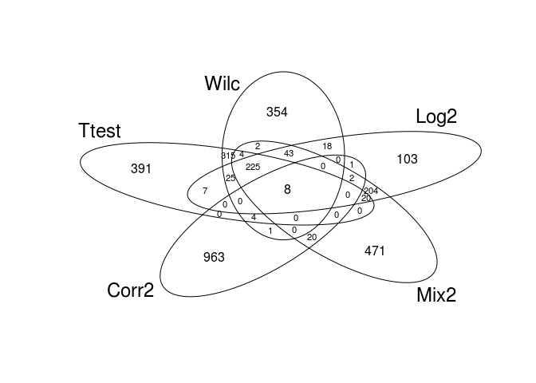

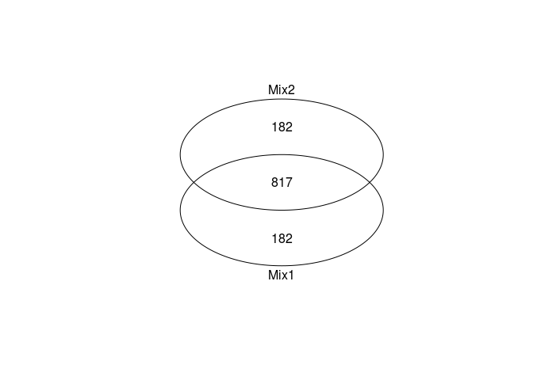

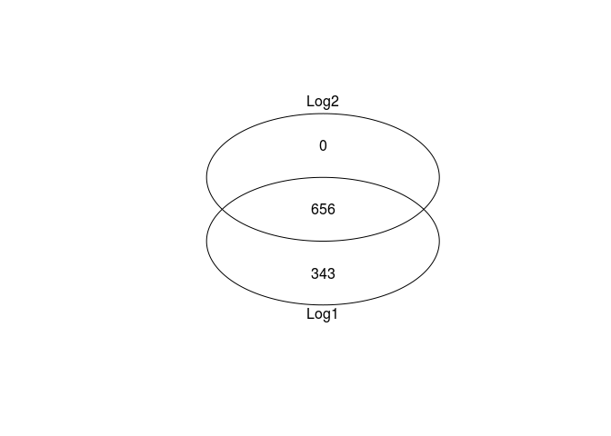

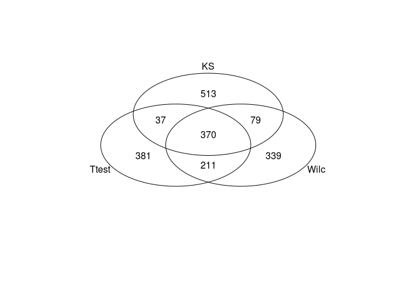

### 3.1.8 Rozkłady top 1000 każdej z metod

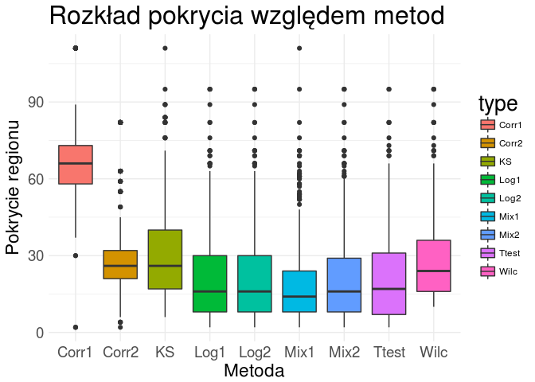

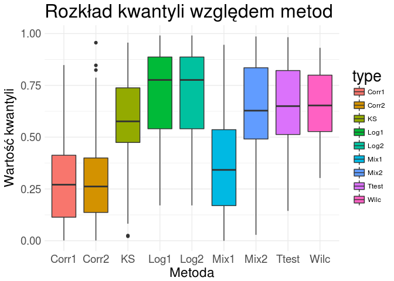

## 3.2 p = 0.04

```
## [1] "Ilosc regionów: 392280"
```

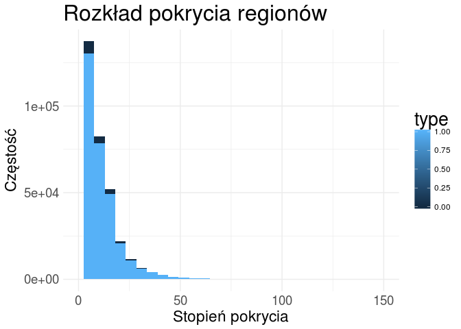

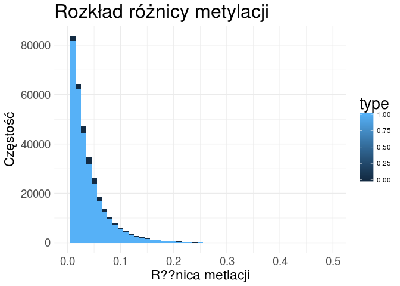

### 3.2.1 tTest:

```
## [1] "Ile brak?w danych: 34928"
```

|  | type | prob_name | met_max_EK | met_max_EU | met_mean_EK | met_mean_EU | met_min_EK | met_min_EU | met_n_EK | met_n_EU | met_sd_EK | met_sd_EU | met_diff | quantile |
| --- | --- | --- | --- | --- | --- | --- | --- | --- | --- | --- | --- | --- | --- | --- |
| 1 | 0 | 92462_9 | 0.0769230769230769 | 0.208333333333333 | 0.00345314950578108 | 0.0446839898962864 | 0 | 0 | 60 | 60 | 0.0145799060711754 | 0.0352596896829431 | 0.0412308403905053 | 0.752589039112039 |
| 2 | 0 | 112430_19 | 0.0238095238095238 | 0.0952380952380952 | 0.00196874615479267 | 0.0399604021372919 | 0 | 0.0116279069767442 | 43 | 43 | 0.0058235316517469 | 0.0191279434359901 | 0.0379916559824993 | 0.71341146868887 |
| 3 | 0 | 19147_10 | 0.0303030303030303 | 0.122448979591837 | 0.00433830399527878 | 0.0500244483037693 | 0 | 0 | 41 | 41 | 0.00878620346339408 | 0.0237105722364105 | 0.0456861443084905 | 0.758212949021479 |
| 4 | 0 | 84815_22 | 0.0454545454545455 | 0.136363636363636 | 0.00977217125791687 | 0.0657448069019307 | 0 | 0 | 48 | 48 | 0.0147047334452074 | 0.0325746173522034 | 0.0559726356440138 | 0.810824434819643 |
| 5 | 0 | 107643_20 | 0.0357142857142857 | 0.120689655172414 | 0.0071891410072801 | 0.0521725946412663 | 0 | 0 | 48 | 48 | 0.0108611461662156 | 0.0259915466694892 | 0.0449834536339862 | 0.762758882525718 |
| 6 | 0 | 112430_23 | 0.0238095238095238 | 0.0919540229885057 | 0.00204624235631988 | 0.0397621272608152 | 0 | 0 | 43 | 43 | 0.00537104102293767 | 0.021703945639217 | 0.0377158849044953 | 0.71109306864508 |
| 7 | 0 | 30544_26 | 0.0769230769230769 | 0.120689655172414 | 0.0016366612111293 | 0.0479781671262111 | 0 | 0 | 47 | 47 | 0.0112203839613765 | 0.027332104152442 | 0.0463415059150818 | 0.769280872144244 |
| 8 | 0 | 66093_13 | 0.0072992700729927 | 0.125 | 0.00050761642268807 | 0.0451880843434566 | 0 | 0 | 57 | 57 | 0.00186421272492075 | 0.0348814747111759 | 0.0446804679207685 | 0.77013412004451 |
| 9 | 0 | 124405_7 | 0.05 | 0.121212121212121 | 0.00589456996829398 | 0.0451873380580822 | 0 | 0 | 69 | 69 | 0.0144597872621162 | 0.0313247275832277 | 0.0392927680897882 | 0.747939747458174 |
| 10 | 0 | 112430_28 | 0.0238095238095238 | 0.123076923076923 | 0.000844407530454042 | 0.0430760428191726 | 0 | 0 | 43 | 43 | 0.00406050486159729 | 0.0269684255058589 | 0.0422316352887185 | 0.741587316232961 |

[output cut: 90 more lines]

### 3.2.2 Wilcoxon:

```
## [1] "Ile brak?w danych: 9121"
```

|  | type | prob_name | met_max_EK | met_max_EU | met_mean_EK | met_mean_EU | met_min_EK | met_min_EU | met_n_EK | met_n_EU | met_sd_EK | met_sd_EU | met_diff | quantile |
| --- | --- | --- | --- | --- | --- | --- | --- | --- | --- | --- | --- | --- | --- | --- |
| 1 | 0 | 124405_7 | 0.05 | 0.121212121212121 | 0.00589456996829398 | 0.0451873380580822 | 0 | 0 | 69 | 69 | 0.0144597872621162 | 0.0313247275832277 | 0.0392927680897882 | 0.747939747458174 |
| 2 | 0 | 92462_9 | 0.0769230769230769 | 0.208333333333333 | 0.00345314950578108 | 0.0446839898962864 | 0 | 0 | 60 | 60 | 0.0145799060711754 | 0.0352596896829431 | 0.0412308403905053 | 0.752589039112039 |
| 3 | 0 | 107301_5 | 0.166666666666667 | 0.2 | 0.0179162791491849 | 0.0620206899639195 | 0 | 0 | 89 | 89 | 0.0319301193307522 | 0.0419177025743078 | 0.0441044108147346 | 0.786846576917064 |
| 4 | 0 | 100895_1 | 0.0714285714285714 | 0.166666666666667 | 0.00453736822665887 | 0.052990313612827 | 0 | 0 | 61 | 61 | 0.0142135431480139 | 0.0412530473007759 | 0.0484529453861681 | 0.79142978482104 |
| 5 | 0 | 23508_26 | 0.1 | 0.258064516129032 | 0.0360574674828409 | 0.0874457446368707 | 0 | 0 | 82 | 82 | 0.0322146209235358 | 0.0580419846045986 | 0.0513882771540298 | 0.813561072434097 |
| 6 | 0 | 84815_22 | 0.0454545454545455 | 0.136363636363636 | 0.00977217125791687 | 0.0657448069019307 | 0 | 0 | 48 | 48 | 0.0147047334452074 | 0.0325746173522034 | 0.0559726356440138 | 0.810824434819643 |
| 7 | 0 | 107643_20 | 0.0357142857142857 | 0.120689655172414 | 0.0071891410072801 | 0.0521725946412663 | 0 | 0 | 48 | 48 | 0.0108611461662156 | 0.0259915466694892 | 0.0449834536339862 | 0.762758882525718 |
| 8 | 0 | 124405_6 | 0.08 | 0.12 | 0.00882195775092004 | 0.0462367890745487 | 0 | 0 | 69 | 69 | 0.0188260804541821 | 0.031596257915341 | 0.0374148313236286 | 0.736481162825049 |
| 9 | 0 | 66093_13 | 0.0072992700729927 | 0.125 | 0.00050761642268807 | 0.0451880843434566 | 0 | 0 | 57 | 57 | 0.00186421272492075 | 0.0348814747111759 | 0.0446804679207685 | 0.77013412004451 |
| 10 | 0 | 148762_13 | 0.0714285714285714 | 0.230769230769231 | 0.00839413122151217 | 0.0471744591420196 | 0 | 0 | 66 | 66 | 0.0181861918147666 | 0.0408349006879256 | 0.0387803279205074 | 0.742881972767966 |

[output cut: 90 more lines]

### 3.2.3 KSTest:

```
## [1] "Ile brak?w danych: 0"
```

|  | type | prob_name | met_max_EK | met_max_EU | met_mean_EK | met_mean_EU | met_min_EK | met_min_EU | met_n_EK | met_n_EU | met_sd_EK | met_sd_EU | met_diff | quantile |
| --- | --- | --- | --- | --- | --- | --- | --- | --- | --- | --- | --- | --- | --- | --- |
| 1 | 0 | 124405_7 | 0.05 | 0.121212121212121 | 0.00589456996829398 | 0.0451873380580822 | 0 | 0 | 69 | 69 | 0.0144597872621162 | 0.0313247275832277 | 0.0392927680897882 | 0.747939747458174 |
| 2 | 0 | 92462_9 | 0.0769230769230769 | 0.208333333333333 | 0.00345314950578108 | 0.0446839898962864 | 0 | 0 | 60 | 60 | 0.0145799060711754 | 0.0352596896829431 | 0.0412308403905053 | 0.752589039112039 |
| 3 | 0 | 30544_26 | 0.0769230769230769 | 0.120689655172414 | 0.0016366612111293 | 0.0479781671262111 | 0 | 0 | 47 | 47 | 0.0112203839613765 | 0.027332104152442 | 0.0463415059150818 | 0.769280872144244 |
| 4 | 0 | 112430_19 | 0.0238095238095238 | 0.0952380952380952 | 0.00196874615479267 | 0.0399604021372919 | 0 | 0.0116279069767442 | 43 | 43 | 0.0058235316517469 | 0.0191279434359901 | 0.0379916559824993 | 0.71341146868887 |
| 5 | 0 | 112430_23 | 0.0238095238095238 | 0.0919540229885057 | 0.00204624235631988 | 0.0397621272608152 | 0 | 0 | 43 | 43 | 0.00537104102293767 | 0.021703945639217 | 0.0377158849044953 | 0.71109306864508 |
| 6 | 0 | 66093_13 | 0.0072992700729927 | 0.125 | 0.00050761642268807 | 0.0451880843434566 | 0 | 0 | 57 | 57 | 0.00186421272492075 | 0.0348814747111759 | 0.0446804679207685 | 0.77013412004451 |
| 7 | 0 | 112430_28 | 0.0238095238095238 | 0.123076923076923 | 0.000844407530454042 | 0.0430760428191726 | 0 | 0 | 43 | 43 | 0.00406050486159729 | 0.0269684255058589 | 0.0422316352887185 | 0.741587316232961 |
| 8 | 0 | 19147_10 | 0.0303030303030303 | 0.122448979591837 | 0.00433830399527878 | 0.0500244483037693 | 0 | 0 | 41 | 41 | 0.00878620346339408 | 0.0237105722364105 | 0.0456861443084905 | 0.758212949021479 |
| 9 | 0 | 100895_1 | 0.0714285714285714 | 0.166666666666667 | 0.00453736822665887 | 0.052990313612827 | 0 | 0 | 61 | 61 | 0.0142135431480139 | 0.0412530473007759 | 0.0484529453861681 | 0.79142978482104 |
| 10 | 0 | 107301_5 | 0.166666666666667 | 0.2 | 0.0179162791491849 | 0.0620206899639195 | 0 | 0 | 89 | 89 | 0.0319301193307522 | 0.0419177025743078 | 0.0441044108147346 | 0.786846576917064 |

[output cut: 90 more lines]

### 3.2.4 Regresja logistyczna:

```
## [1] "Ile braków danych: 29370"
```

Szeregowanie po pValue:

|  | type | pValue | prob_name | met_max_EK | met_max_EU | met_mean_EK | met_mean_EU | met_min_EK | met_min_EU | met_n_EK | met_n_EU | met_sd_EK | met_sd_EU | met_diff | quantile |
| --- | --- | --- | --- | --- | --- | --- | --- | --- | --- | --- | --- | --- | --- | --- | --- |
| 1 | 0 | 3.62732010421012e-25 | 64601_13 | 0.0769230769230769 | 0.2 | 0.00409519190262268 | 0.039691811143255 | 0 | 0 | 54 | 54 | 0.0147208390254571 | 0.0395348825769115 | 0.0355966192406324 | 0.709287856830263 |
| 2 | 0 | 2.27480486826742e-21 | 64601_12 | 0.0102564102564103 | 0.2 | 0.000767949353811327 | 0.0382855143538763 | 0 | 0 | 54 | 54 | 0.00253175843903359 | 0.0465314589839572 | 0.037517565000065 | 0.724239479011997 |
| 3 | 0 | 3.89287930991967e-20 | 100209_21 | 0.0476190476190476 | 0.111111111111111 | 0.0150343911423531 | 0.0568751266522983 | 0 | 0 | 50 | 50 | 0.0146494693187251 | 0.028060642235179 | 0.0418407355099452 | 0.747005289531311 |
| 4 | 0 | 3.56915616617374e-17 | 49354_2 | 1 | 1 | 0.888096416117545 | 0.950253927644024 | 0.733333333333333 | 0.888888888888889 | 39 | 39 | 0.0621629177274504 | 0.0288868268408875 | 0.0621575115264792 | 0.823681294011489 |
| 5 | 0 | 1.14711368315368e-16 | 5461_1 | 0.0290697674418605 | 0.0773480662983425 | 0.00632897681739058 | 0.0482241577605701 | 0 | 0.0222222222222222 | 17 | 17 | 0.00874260423683563 | 0.0175702424622241 | 0.0418951809431795 | 0.680929761124686 |
| 6 | 0 | 3.81302398899109e-16 | 5461_22 | 0.0197368421052632 | 0.0666666666666667 | 0.00604488549219242 | 0.046834686642027 | 0 | 0.0227272727272727 | 17 | 17 | 0.00723095267563224 | 0.0141659428144731 | 0.0407898011498346 | 0.673154725870147 |
| 7 | 0 | 4.18152200305995e-16 | 74071_20 | 0.0115606936416185 | 0.172413793103448 | 0.00226145015409488 | 0.0525818005541532 | 0 | 0 | 25 | 25 | 0.00366156881810626 | 0.0420487727722971 | 0.0503203504000583 | 0.75498727027969 |
| 8 | 0 | 1.98410970324987e-15 | 150945_27 | 0.0909090909090909 | 0.125 | 0.0191333821393921 | 0.0716189815949373 | 0 | 0 | 35 | 35 | 0.0222537065326795 | 0.0362285862159219 | 0.0524855994555451 | 0.783956270569855 |
| 9 | 0 | 2.98255304099999e-15 | 84815_22 | 0.0454545454545455 | 0.136363636363636 | 0.00977217125791687 | 0.0657448069019307 | 0 | 0 | 48 | 48 | 0.0147047334452074 | 0.0325746173522034 | 0.0559726356440138 | 0.810824434819643 |
| 10 | 0 | 3.56715709138604e-15 | 14042_20 | 1 | 1 | 0.868675031312407 | 0.938040677399717 | 0.692307692307692 | 0.846153846153846 | 31 | 31 | 0.0809122042603155 | 0.0375853903208094 | 0.0693656460873104 | 0.835508292594912 |

[output cut: 90 more lines]

Szeregowane po beta:

|  | type | pValue | prob_name | met_max_EK | met_max_EU | met_mean_EK | met_mean_EU | met_min_EK | met_min_EU | met_n_EK | met_n_EU | met_sd_EK | met_sd_EU | met_diff | quantile |
| --- | --- | --- | --- | --- | --- | --- | --- | --- | --- | --- | --- | --- | --- | --- | --- |
| 1 | 0 | 1.04755644531352e-05 | 72936_15 | 0.0123456790123457 | 0.272727272727273 | 0.000363108206245461 | 0.0505742160569434 | 0 | 0 | 34 | 34 | 0.00211726648324085 | 0.0534991076385631 | 0.0502111078506979 | 0.771992349268826 |
| 2 | 0 | 1.4491286061461e-05 | 30544_26 | 0.0769230769230769 | 0.120689655172414 | 0.0016366612111293 | 0.0479781671262111 | 0 | 0 | 47 | 47 | 0.0112203839613765 | 0.027332104152442 | 0.0463415059150818 | 0.769280872144244 |
| 3 | 0 | 4.29390243221653e-05 | 21467_17 | 0.012987012987013 | 0.0675675675675676 | 0.000721500721500722 | 0.0430413747080414 | 0 | 0.0131578947368421 | 18 | 18 | 0.00306106831682488 | 0.0189817181622501 | 0.0423198739865407 | 0.688237121013355 |
| 4 | 0 | 9.90872842790814e-09 | 112430_28 | 0.0238095238095238 | 0.123076923076923 | 0.000844407530454042 | 0.0430760428191726 | 0 | 0 | 43 | 43 | 0.00406050486159729 | 0.0269684255058589 | 0.0422316352887185 | 0.741587316232961 |
| 5 | 0 | 5.08598841342032e-05 | 141438_2 | 0.0526315789473684 | 0.121212121212121 | 0.00142247510668563 | 0.0429889609660441 | 0 | 0 | 37 | 37 | 0.00865257827922932 | 0.0274874306506879 | 0.0415664858593585 | 0.729042135008826 |
| 6 | 0 | 5.39819377104051e-05 | 8009_5 | 0.0128205128205128 | 0.0683760683760684 | 0.000512820512820513 | 0.0363142961058874 | 0 | 0 | 25 | 25 | 0.00256410256410256 | 0.0185561254539226 | 0.0358014755930669 | 0.66450429323239 |
| 7 | 0 | 6.36364521411323e-05 | 26331_22 | 0.0555555555555556 | 0.2 | 0.000896057347670251 | 0.0537430308243957 | 0 | 0 | 62 | 62 | 0.0070555626111217 | 0.0523731626206348 | 0.0528469734767254 | 0.809073445706386 |
| 8 | 0 | 6.30018262877922e-05 | 39989_28 | 0.0333333333333333 | 0.166666666666667 | 0.000617283950617284 | 0.0396544511131892 | 0 | 0 | 54 | 54 | 0.00453609211626514 | 0.0358387784236102 | 0.0390371671625719 | 0.734158721354276 |
| 9 | 0 | 6.83249685481778e-05 | 77427_7 | 0.0144927536231884 | 0.103448275862069 | 0.000579710144927536 | 0.0450502067933192 | 0 | 0 | 25 | 25 | 0.00289855072463768 | 0.0319297274270803 | 0.0444704966483916 | 0.723120899961399 |
| 10 | 0 | 2.09789867883714e-08 | 73097_11 | 0.0099009900990099 | 0.0882352941176471 | 0.000594234180699623 | 0.0451625703880164 | 0 | 0 | 33 | 33 | 0.00237589736484041 | 0.0234381662737035 | 0.0445683362073168 | 0.740467583077531 |

[output cut: 90 more lines]

### 3.2.5 Regresja logistyczna z efektami losowymi:

```
## [1] "Ile braków danych: 34843"
```

Szeregowanie po pValue:

|  | type | pValue | prob_name | met_max_EK | met_max_EU | met_mean_EK | met_mean_EU | met_min_EK | met_min_EU | met_n_EK | met_n_EU | met_sd_EK | met_sd_EU | met_diff | quantile |
| --- | --- | --- | --- | --- | --- | --- | --- | --- | --- | --- | --- | --- | --- | --- | --- |
| 1 | 1 | 0 | 14030_1 | 0.0769230769230769 | 0.134615384615385 | 0.0187220187220187 | 0.051551959293034 | 0 | 0 | 14 | 14 | 0.0246024928932966 | 0.0374226201098881 | 0.0328299405710153 | 0.587117506010143 |
| 2 | 0 | 0 | 22894_1 | 0.0384615384615385 | 0.157894736842105 | 0.00247568523430592 | 0.0515569424332902 | 0 | 0 | 29 | 29 | 0.00928258651596414 | 0.0407236509471925 | 0.0490812571989842 | 0.757161187249442 |
| 3 | 1 | 0 | 32467_1 | 0.08 | 0.152173913043478 | 0.0352083333333333 | 0.0589153561517114 | 0 | 0 | 8 | 8 | 0.0396756442421764 | 0.053834256544166 | 0.023707022818378 | 0.430853656889756 |
| 4 | 1 | 0 | 66334_1 | 1 | 1 | 0.954511385199241 | 0.931707827056664 | 0.870967741935484 | 0.857142857142857 | 17 | 17 | 0.0431253107654074 | 0.0440105572084094 | 0.0228035581425767 | 0.484207380458477 |
| 5 | 1 | 0 | 71203_1 | 1 | 1 | 0.914992414992415 | 0.891387559808612 | 0.769230769230769 | 0.736842105263158 | 11 | 11 | 0.0763630326160484 | 0.0748136272443433 | 0.0236048551838026 | 0.456615786327732 |
| 6 | 1 | 0 | 76031_1 | 1 | 0.967391304347826 | 1 | 0.928140096618358 | 1 | 0.888888888888889 | 2 | 2 | 0 | 0.0555095903105382 | 0.0718599033816425 | 0.661145726573332 |
| 7 | 1 | 0 | 84433_1 | 1 | 1 | 0.995670995670996 | 1 | 0.909090909090909 | 1 | 21 | 21 | 0.0198379900214539 | 0 | 0.00432900432900429 | 0.125658433842183 |
| 8 | 1 | 0 | 89874_1 | 0.181818181818182 | 0.172413793103448 | 0.0406005112164935 | 0.0541548750181493 | 0 | 0 | 42 | 42 | 0.0506255611834864 | 0.0483217915182603 | 0.0135543638016559 | 0.394380963341251 |
| 9 | 0 | 0 | 96653_1 | 0.0833333333333333 | 0.212121212121212 | 0.00688256000248614 | 0.0483639213192655 | 0 | 0 | 52 | 52 | 0.0168082031046893 | 0.0473706058692883 | 0.0414813613167794 | 0.746926822572703 |
| 10 | 1 | 0 | 102038_1 | 1 | 1 | 0.901041666666667 | 0.944444444444444 | 0.8 | 0.888888888888889 | 4 | 4 | 0.0866275953595491 | 0.0453609211626515 | 0.0434027777777777 | 0.561767524944898 |

[output cut: 90 more lines]

Szeregowane po beta:

|  | type | pValue | prob_name | met_max_EK | met_max_EU | met_mean_EK | met_mean_EU | met_min_EK | met_min_EU | met_n_EK | met_n_EU | met_sd_EK | met_sd_EU | met_diff | quantile |
| --- | --- | --- | --- | --- | --- | --- | --- | --- | --- | --- | --- | --- | --- | --- | --- |
| 1 | 0 | 0 | 21467_18 | 0 | 0.105263157894737 | 0 | 0.0414500026342132 | 0 | 0 | 18 | 18 | 0 | 0.0267524999637707 | 0.0414500026342132 | 0.68215578846794 |
| 2 | 0 | 0 | 142551_23 | 0 | 0.0882352941176471 | 0 | 0.0347809670964974 | 0 | 0 | 15 | 15 | 0 | 0.0269534203790232 | 0.0347809670964974 | 0.61209637050163 |
| 3 | 1 | 0 | 84433_5 | 1 | 1 | 0.995670995670996 | 1 | 0.909090909090909 | 1 | 21 | 21 | 0.0198379900214539 | 0 | 0.00432900432900429 | 0.125658433842183 |
| 4 | 1 | 0 | 84433_1 | 1 | 1 | 0.995670995670996 | 1 | 0.909090909090909 | 1 | 21 | 21 | 0.0198379900214539 | 0 | 0.00432900432900429 | 0.125658433842183 |
| 5 | 1 | 0 | 84433_20 | 1 | 1 | 0.995670995670996 | 1 | 0.909090909090909 | 1 | 21 | 21 | 0.0198379900214539 | 0 | 0.00432900432900429 | 0.125658433842183 |
| 6 | 1 | 0 | 84433_22 | 1 | 1 | 0.995670995670996 | 1 | 0.909090909090909 | 1 | 21 | 21 | 0.0198379900214539 | 0 | 0.00432900432900429 | 0.125658433842183 |
| 7 | 0 | 1.10351138746541e-05 | 72936_15 | 0.0123456790123457 | 0.272727272727273 | 0.000363108206245461 | 0.0505742160569434 | 0 | 0 | 34 | 34 | 0.00211726648324085 | 0.0534991076385631 | 0.0502111078506979 | 0.771992349268826 |
| 8 | 0 | 1.84578952393933e-05 | 30544_26 | 0.0769230769230769 | 0.120689655172414 | 0.0016366612111293 | 0.0479781671262111 | 0 | 0 | 47 | 47 | 0.0112203839613765 | 0.027332104152442 | 0.0463415059150818 | 0.769280872144244 |
| 9 | 0 | 4.42472939332048e-05 | 21467_17 | 0.012987012987013 | 0.0675675675675676 | 0.000721500721500722 | 0.0430413747080414 | 0 | 0.0131578947368421 | 18 | 18 | 0.00306106831682488 | 0.0189817181622501 | 0.0423198739865407 | 0.688237121013355 |
| 10 | 0 | 1.03981691900208e-08 | 112430_28 | 0.0238095238095238 | 0.123076923076923 | 0.000844407530454042 | 0.0430760428191726 | 0 | 0 | 43 | 43 | 0.00406050486159729 | 0.0269684255058589 | 0.0422316352887185 | 0.741587316232961 |

[output cut: 90 more lines]

### 3.2.6 Regresja logistyczna z efektami losowymi z uwzględnieniem korelacji:

```
## [1] "Ile braków danych: 31194"
```

Szeregowanie po pValue:

|  | type | pValue | prob_name | met_max_EK | met_max_EU | met_mean_EK | met_mean_EU | met_min_EK | met_min_EU | met_n_EK | met_n_EU | met_sd_EK | met_sd_EU | met_diff | quantile |
| --- | --- | --- | --- | --- | --- | --- | --- | --- | --- | --- | --- | --- | --- | --- | --- |
| 1 | 1 | 1.29127501688278e-20 | 44349_9 | 0.5 | 0.454545454545455 | 0.277598178456511 | 0.248311059118378 | 0.0769230769230769 | 0.0476190476190476 | 70 | 70 | 0.0869707445075725 | 0.0810112373657715 | 0.0292871193381338 | 0.678844636170651 |
| 2 | 1 | 5.13419548375876e-20 | 44349_10 | 0.529411764705882 | 0.818181818181818 | 0.264812988543197 | 0.256212607098368 | 0.0666666666666667 | 0 | 70 | 70 | 0.104969170510899 | 0.117863069507824 | 0.008600381444829 | 0.305788577430596 |
| 3 | 1 | 9.69895913935325e-20 | 27239_20 | 0.25 | 0.294117647058824 | 0.0824219502955135 | 0.0776032000814711 | 0 | 0 | 111 | 111 | 0.0650983140075297 | 0.0625921727873679 | 0.00481875021404236 | 0.198454790497975 |
| 4 | 1 | 1.11078991651199e-19 | 44349_30 | 0.647058823529412 | 0.419354838709677 | 0.269153651494525 | 0.23202674935609 | 0 | 0 | 70 | 70 | 0.129305801917401 | 0.0904763323097634 | 0.0371269021384349 | 0.735280736039939 |
| 5 | 1 | 1.37171496612246e-19 | 27239_16 | 0.333333333333333 | 0.294117647058824 | 0.0851417118083785 | 0.0740447451658438 | 0 | 0 | 111 | 111 | 0.0710434068797427 | 0.0661549521762393 | 0.0110969666425347 | 0.402363198867876 |
| 6 | 1 | 1.53961135621333e-19 | 27239_11 | 0.333333333333333 | 0.230769230769231 | 0.0766042360869947 | 0.0679240639782309 | 0 | 0 | 111 | 111 | 0.0687028974378797 | 0.0510920424957726 | 0.00868017210876379 | 0.335704902332693 |
| 7 | 1 | 2.02792431715021e-19 | 27239_13 | 0.333333333333333 | 0.272727272727273 | 0.0779962015019486 | 0.0742117152825402 | 0 | 0 | 111 | 111 | 0.0643437500491898 | 0.0604486706854949 | 0.00378448621940845 | 0.151279738776216 |
| 8 | 1 | 2.03688559901651e-19 | 27239_17 | 0.346153846153846 | 0.307692307692308 | 0.0733011381861957 | 0.0765059428785737 | 0 | 0 | 111 | 111 | 0.0656926320040796 | 0.0597425530792798 | 0.00320480469237804 | 0.122645184674322 |
| 9 | 1 | 2.07452691169399e-19 | 27239_19 | 0.333333333333333 | 0.384615384615385 | 0.080680232519313 | 0.0712274949270304 | 0 | 0 | 111 | 111 | 0.0719089766375387 | 0.0627975856094079 | 0.00945273759228261 | 0.357436576718933 |
| 10 | 1 | 2.28815496324054e-19 | 27239_3 | 0.25 | 0.307692307692308 | 0.073641389963229 | 0.0823196187691596 | 0 | 0 | 111 | 111 | 0.0652098383499589 | 0.065217761729606 | 0.00867822880593061 | 0.335646725509939 |

[output cut: 90 more lines]

Szeregowane po beta:

|  | type | pValue | prob_name | met_max_EK | met_max_EU | met_mean_EK | met_mean_EU | met_min_EK | met_min_EU | met_n_EK | met_n_EU | met_sd_EK | met_sd_EU | met_diff | quantile |
| --- | --- | --- | --- | --- | --- | --- | --- | --- | --- | --- | --- | --- | --- | --- | --- |
| 1 | 1 | 2.31574138334587e-05 | 812_2 | 1 | 1 | 0.994949494949495 | 0.995495495495496 | 0.96969696969697 | 0.972972972972973 | 6 | 6 | 0.0123711603170867 | 0.0110337375801044 | 0.000546000546000625 | 0.0219892334203611 |
| 2 | 0 | 6.00206334620662e-06 | 95802_18 | 0.904255319148936 | 0.96969696969697 | 0.866669614912896 | 0.931080785663342 | 0.838095238095238 | 0.90625 | 8 | 8 | 0.0222805073660225 | 0.0233327155384435 | 0.0644111707504457 | 0.747749574928641 |
| 3 | 1 | 3.73087528559635e-15 | 110307_1 | 1 | 0.979166666666667 | 0.927261904761905 | 0.94041270382031 | 0.833333333333333 | 0.872340425531915 | 14 | 14 | 0.0503305617459754 | 0.0317921912649591 | 0.0131507990584054 | 0.309238049922584 |
| 4 | 1 | 0.000926252939458593 | 138909_2 | 1 | 0.923076923076923 | 0.875 | 0.865384615384615 | 0.7 | 0.846153846153846 | 4 | 4 | 0.15 | 0.0384615384615385 | 0.00961538461538458 | 0.18040088435368 |
| 5 | 1 | 2.11774488588598e-07 | 32119_26 | 0.925 | 0.9375 | 0.763785096426546 | 0.788532913165266 | 0.658536585365854 | 0.685714285714286 | 8 | 8 | 0.0814398934589484 | 0.0834054943656489 | 0.0247478167387204 | 0.44415314473445 |
| 6 | 1 | 0.000502053718528021 | 76969_6 | 0.795833333333333 | 0.790794979079498 | 0.776764915229475 | 0.774260624480287 | 0.747899159663866 | 0.747899159663866 | 4 | 4 | 0.0216917424970177 | 0.0198091866351467 | 0.00250429074918734 | 0.0673559968398636 |
| 7 | 1 | 1.06192792952943e-07 | 140165_23 | 1 | 1 | 0.9 | 0.9296875 | 0.7 | 0.833333333333333 | 8 | 8 | 0.10690449676497 | 0.0645537246516583 | 0.0296875 | 0.501982931242801 |
| 8 | 1 | 0.000188310707922593 | 47154_15 | 1 | 0.954545454545455 | 0.903947368421053 | 0.865283267457181 | 0.789473684210526 | 0.681818181818182 | 6 | 6 | 0.0909133403690774 | 0.109789086425062 | 0.0386641009638721 | 0.562319886552743 |
| 9 | 1 | 4.41393799255698e-08 | 65837_2 | 1 | 1 | 0.884057609057609 | 0.936928104575163 | 0.666666666666667 | 0.764705882352941 | 10 | 10 | 0.100194187709401 | 0.0752982592361313 | 0.0528704955175543 | 0.707577756837775 |
| 10 | 1 | 0.000182674287576354 | 29107_8 | 1 | 1 | 0.962732919254658 | 0.9375 | 0.869565217391304 | 0.875 | 7 | 7 | 0.0464802159847695 | 0.0625 | 0.0252329192546584 | 0.438666192678759 |

[output cut: 90 more lines]

### 3.2.7 Podsumowanie

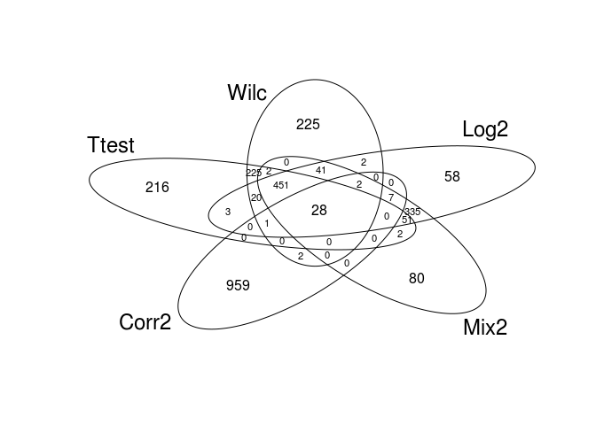

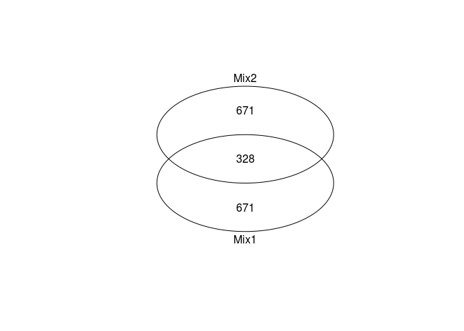

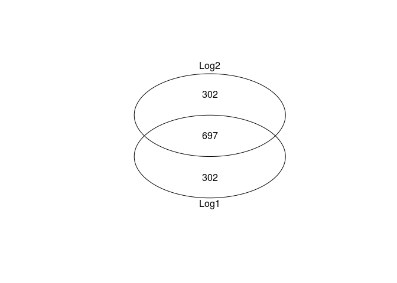

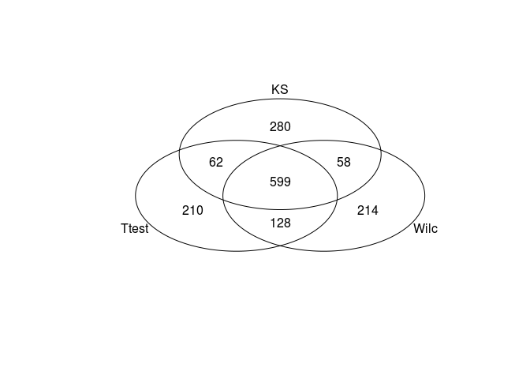

### 3.2.8 Rozk?ady top 1000 każdej z metod

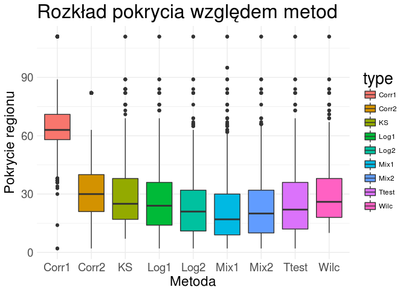

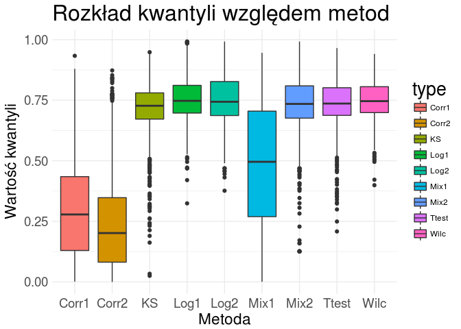

## 3.3 p = 0.06

```
## [1] "Ilosc regionów: 392280"
```

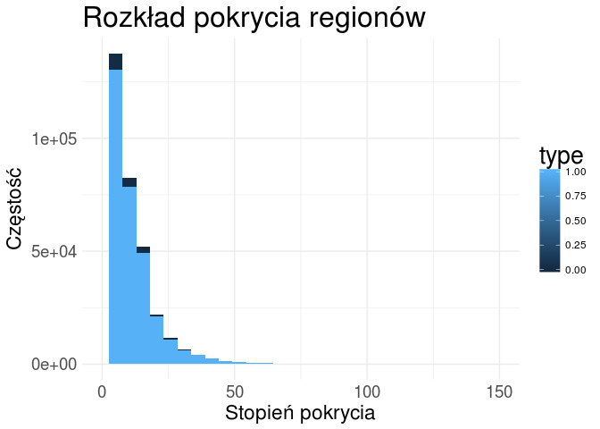

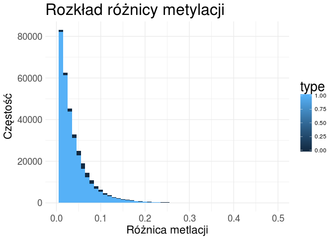

### 3.3.1 tTest:

```
## [1] "Ile braków danych: 38964"
```

|  | type | prob_name | met_max_EK | met_max_EU | met_mean_EK | met_mean_EU | met_min_EK | met_min_EU | met_n_EK | met_n_EU | met_sd_EK | met_sd_EU | met_diff | quantile |
| --- | --- | --- | --- | --- | --- | --- | --- | --- | --- | --- | --- | --- | --- | --- |
| 1 | 0 | 107301_16 | 0.1 | 0.230769230769231 | 0.0173122165871506 | 0.084223026301553 | 0 | 0 | 89 | 89 | 0.0295294463033197 | 0.0449012285370345 | 0.0669108097144024 | 0.860538233927115 |
| 2 | 0 | 124405_4 | 0.1 | 0.2 | 0.00646316790398254 | 0.0677467174839887 | 0 | 0 | 69 | 69 | 0.0174938184077224 | 0.0396363721691438 | 0.0612835495800062 | 0.838963083652575 |
| 3 | 0 | 112430_9 | 0.0135135135135135 | 0.111111111111111 | 0.00147761775668752 | 0.0636154947343262 | 0 | 0.0232558139534884 | 43 | 43 | 0.00412495510085985 | 0.023805891251609 | 0.0621378769776386 | 0.827088477565406 |
| 4 | 0 | 44163_12 | 0.0476190476190476 | 0.181818181818182 | 0.00440743955591462 | 0.0589304535661207 | 0 | 0 | 71 | 71 | 0.0119334966548329 | 0.0391635375112743 | 0.0545230140102061 | 0.820209732516927 |
| 5 | 0 | 124405_29 | 0.0526315789473684 | 0.129032258064516 | 0.00490019419479175 | 0.059188427915745 | 0 | 0 | 69 | 69 | 0.0142459380817475 | 0.0323658322729228 | 0.0542882337209532 | 0.818330872048868 |
| 6 | 0 | 44163_10 | 0.0303030303030303 | 0.16 | 0.00219017167843569 | 0.0614851460207147 | 0 | 0 | 71 | 71 | 0.006918402623763 | 0.0427356371487425 | 0.059294974342279 | 0.8344120020106 |
| 7 | 0 | 124405_11 | 0.05 | 0.171428571428571 | 0.00459022214220702 | 0.0673258567393075 | 0 | 0 | 69 | 69 | 0.0127541468061602 | 0.0422180991850861 | 0.0627356345971005 | 0.843067785715493 |
| 8 | 0 | 107643_22 | 0.0263157894736842 | 0.145454545454545 | 0.00130847953216374 | 0.0584384142589065 | 0 | 0 | 48 | 48 | 0.00475181275683845 | 0.0308260140676371 | 0.0571299347267428 | 0.814972207908517 |
| 9 | 0 | 26240_7 | 0.0138888888888889 | 0.111111111111111 | 0.00068968797564688 | 0.0563800554762335 | 0 | 0 | 40 | 40 | 0.00304465450883152 | 0.0250426771706519 | 0.0556903675005866 | 0.802549706239582 |
| 10 | 0 | 27239_12 | 0.153846153846154 | 0.333333333333333 | 0.0261654378895758 | 0.0996515771381363 | 0 | 0 | 111 | 111 | 0.0357761178648061 | 0.0715885927023383 | 0.0734861392485605 | 0.877965572030932 |

[output cut: 90 more lines]

### 3.3.2 Wilcoxon:

```
## [1] "Ile braków danych: 13973"
```

|  | type | prob_name | met_max_EK | met_max_EU | met_mean_EK | met_mean_EU | met_min_EK | met_min_EU | met_n_EK | met_n_EU | met_sd_EK | met_sd_EU | met_diff | quantile |
| --- | --- | --- | --- | --- | --- | --- | --- | --- | --- | --- | --- | --- | --- | --- |
| 1 | 0 | 107301_16 | 0.1 | 0.230769230769231 | 0.0173122165871506 | 0.084223026301553 | 0 | 0 | 89 | 89 | 0.0295294463033197 | 0.0449012285370345 | 0.0669108097144024 | 0.860538233927115 |
| 2 | 0 | 27239_12 | 0.153846153846154 | 0.333333333333333 | 0.0261654378895758 | 0.0996515771381363 | 0 | 0 | 111 | 111 | 0.0357761178648061 | 0.0715885927023383 | 0.0734861392485605 | 0.877965572030932 |
| 3 | 0 | 98246_20 | 0.0769230769230769 | 0.307692307692308 | 0.00619989684889838 | 0.0609021011950891 | 0 | 0 | 84 | 84 | 0.0172168439596109 | 0.0543878092922207 | 0.0547022043461907 | 0.825833487470603 |
| 4 | 0 | 124405_4 | 0.1 | 0.2 | 0.00646316790398254 | 0.0677467174839887 | 0 | 0 | 69 | 69 | 0.0174938184077224 | 0.0396363721691438 | 0.0612835495800062 | 0.838963083652575 |
| 5 | 0 | 124405_11 | 0.05 | 0.171428571428571 | 0.00459022214220702 | 0.0673258567393075 | 0 | 0 | 69 | 69 | 0.0127541468061602 | 0.0422180991850861 | 0.0627356345971005 | 0.843067785715493 |
| 6 | 0 | 75368_6 | 0.0625 | 0.222222222222222 | 0.00241228070175439 | 0.0623570998735041 | 0 | 0 | 95 | 95 | 0.0108819650966548 | 0.0597333646936015 | 0.0599448191717497 | 0.844188776160999 |
| 7 | 0 | 44163_12 | 0.0476190476190476 | 0.181818181818182 | 0.00440743955591462 | 0.0589304535661207 | 0 | 0 | 71 | 71 | 0.0119334966548329 | 0.0391635375112743 | 0.0545230140102061 | 0.820209732516927 |
| 8 | 0 | 124405_29 | 0.0526315789473684 | 0.129032258064516 | 0.00490019419479175 | 0.059188427915745 | 0 | 0 | 69 | 69 | 0.0142459380817475 | 0.0323658322729228 | 0.0542882337209532 | 0.818330872048868 |
| 9 | 0 | 44163_10 | 0.0303030303030303 | 0.16 | 0.00219017167843569 | 0.0614851460207147 | 0 | 0 | 71 | 71 | 0.006918402623763 | 0.0427356371487425 | 0.059294974342279 | 0.8344120020106 |
| 10 | 0 | 44163_13 | 0.0476190476190476 | 0.210526315789474 | 0.00219000543696855 | 0.0659712045260985 | 0 | 0 | 71 | 71 | 0.00760284977198594 | 0.0498588037357821 | 0.06378119908913 | 0.846946770718641 |

[output cut: 90 more lines]

### 3.3.3 KSTest:

```
## [1] "Ile braków danych: 0"
```

|  | type | prob_name | met_max_EK | met_max_EU | met_mean_EK | met_mean_EU | met_min_EK | met_min_EU | met_n_EK | met_n_EU | met_sd_EK | met_sd_EU | met_diff | quantile |
| --- | --- | --- | --- | --- | --- | --- | --- | --- | --- | --- | --- | --- | --- | --- |
| 1 | 0 | 66093_3 | 0.0769230769230769 | 0.16 | 0.0035801883802888 | 0.0685115744985385 | 0 | 0 | 57 | 57 | 0.0138116251006132 | 0.0437809303961587 | 0.0649313861182498 | 0.843451168110399 |
| 2 | 0 | 124405_4 | 0.1 | 0.2 | 0.00646316790398254 | 0.0677467174839887 | 0 | 0 | 69 | 69 | 0.0174938184077224 | 0.0396363721691438 | 0.0612835495800062 | 0.838963083652575 |
| 3 | 0 | 99102_5 | 0.0285714285714286 | 0.291666666666667 | 0.00215058316567497 | 0.0670618748981171 | 0 | 0 | 44 | 44 | 0.00666928734753248 | 0.044842890738595 | 0.0649112917324422 | 0.835394654393932 |
| 4 | 0 | 107301_7 | 0.166666666666667 | 0.2 | 0.0210249605305963 | 0.0768083550433268 | 0 | 0 | 89 | 89 | 0.0356511291419474 | 0.0445939343718509 | 0.0557833945127304 | 0.83083801238382 |
| 5 | 0 | 87257_8 | 0.037037037037037 | 0.2 | 0.00127713920817369 | 0.0669057171628049 | 0 | 0 | 58 | 58 | 0.00681700829666368 | 0.0483845897279273 | 0.0656285779546312 | 0.84596666385253 |
| 6 | 0 | 100895_9 | 0.0161290322580645 | 0.333333333333333 | 0.00123704496842394 | 0.0740040503106858 | 0 | 0 | 61 | 61 | 0.00385737152203604 | 0.0619273754941189 | 0.0727670053422619 | 0.864271961522018 |
| 7 | 0 | 112430_9 | 0.0135135135135135 | 0.111111111111111 | 0.00147761775668752 | 0.0636154947343262 | 0 | 0.0232558139534884 | 43 | 43 | 0.00412495510085985 | 0.023805891251609 | 0.0621378769776386 | 0.827088477565406 |
| 8 | 0 | 44163_10 | 0.0303030303030303 | 0.16 | 0.00219017167843569 | 0.0614851460207147 | 0 | 0 | 71 | 71 | 0.006918402623763 | 0.0427356371487425 | 0.059294974342279 | 0.8344120020106 |
| 9 | 0 | 124405_11 | 0.05 | 0.171428571428571 | 0.00459022214220702 | 0.0673258567393075 | 0 | 0 | 69 | 69 | 0.0127541468061602 | 0.0422180991850861 | 0.0627356345971005 | 0.843067785715493 |
| 10 | 0 | 44163_12 | 0.0476190476190476 | 0.181818181818182 | 0.00440743955591462 | 0.0589304535661207 | 0 | 0 | 71 | 71 | 0.0119334966548329 | 0.0391635375112743 | 0.0545230140102061 | 0.820209732516927 |

[output cut: 90 more lines]

### 3.3.4 Regresja logistyczna:

```
## [1] "Ile braków danych: 29370"
```

Szeregowanie po pValue:

|  | type | pValue | prob_name | met_max_EK | met_max_EU | met_mean_EK | met_mean_EU | met_min_EK | met_min_EU | met_n_EK | met_n_EU | met_sd_EK | met_sd_EU | met_diff | quantile |
| --- | --- | --- | --- | --- | --- | --- | --- | --- | --- | --- | --- | --- | --- | --- | --- |
| 1 | 0 | 1.65010144709423e-32 | 44163_13 | 0.0476190476190476 | 0.210526315789474 | 0.00219000543696855 | 0.0659712045260985 | 0 | 0 | 71 | 71 | 0.00760284977198594 | 0.0498588037357821 | 0.06378119908913 | 0.846946770718641 |
| 2 | 0 | 4.72763394906214e-30 | 44163_12 | 0.0476190476190476 | 0.181818181818182 | 0.00440743955591462 | 0.0589304535661207 | 0 | 0 | 71 | 71 | 0.0119334966548329 | 0.0391635375112743 | 0.0545230140102061 | 0.820209732516927 |
| 3 | 0 | 9.70546044902389e-30 | 44163_10 | 0.0303030303030303 | 0.16 | 0.00219017167843569 | 0.0614851460207147 | 0 | 0 | 71 | 71 | 0.006918402623763 | 0.0427356371487425 | 0.059294974342279 | 0.8344120020106 |
| 4 | 0 | 2.5721503017475e-27 | 49354_16 | 1 | 1 | 0.905239411211575 | 0.966982045339151 | 0.785714285714286 | 0.888888888888889 | 39 | 39 | 0.0484885905839806 | 0.0256678687463985 | 0.0617426341275761 | 0.82244621052634 |
| 5 | 0 | 5.02237740704087e-27 | 134931_27 | 1 | 1 | 0.91625937765325 | 0.984893110466816 | 0.772727272727273 | 0.942857142857143 | 59 | 59 | 0.0455811719499738 | 0.018203702844328 | 0.0686337328135656 | 0.854163172358179 |
| 6 | 0 | 2.06932008185046e-26 | 14042_3 | 1 | 1 | 0.879666130199807 | 0.965763951335646 | 0.714285714285714 | 0.896551724137931 | 31 | 31 | 0.0697677986043426 | 0.030017844749748 | 0.0860978211358383 | 0.872819575722677 |
| 7 | 0 | 5.95844837948421e-23 | 107301_16 | 0.1 | 0.230769230769231 | 0.0173122165871506 | 0.084223026301553 | 0 | 0 | 89 | 89 | 0.0295294463033197 | 0.0449012285370345 | 0.0669108097144024 | 0.860538233927115 |
| 8 | 0 | 6.12962900473124e-23 | 5459_25 | 0.0425531914893617 | 0.153846153846154 | 0.00646453606585133 | 0.0702077937733101 | 0 | 0 | 35 | 35 | 0.0100450273076996 | 0.046574347215517 | 0.0637432577074588 | 0.824453035446617 |
| 9 | 0 | 3.78286777079388e-22 | 100026_14 | 0.0555555555555556 | 0.263157894736842 | 0.00502844143073663 | 0.064912283516504 | 0 | 0 | 24 | 24 | 0.0117321581797238 | 0.0543228480695481 | 0.0598838420857674 | 0.795203041309313 |
| 10 | 0 | 4.65280012064824e-22 | 6436_9 | 1 | 1 | 0.891112643724312 | 0.971572564896906 | 0.772727272727273 | 0.882352941176471 | 25 | 25 | 0.0533338934271254 | 0.0285644018491792 | 0.0804599211725942 | 0.85521680156003 |

[output cut: 90 more lines]

Szeregowane po beta:

|  | type | pValue | prob_name | met_max_EK | met_max_EU | met_mean_EK | met_mean_EU | met_min_EK | met_min_EU | met_n_EK | met_n_EU | met_sd_EK | met_sd_EU | met_diff | quantile |
| --- | --- | --- | --- | --- | --- | --- | --- | --- | --- | --- | --- | --- | --- | --- | --- |
| 1 | 0 | 2.71742276410761e-06 | 87505_26 | 0.0476190476190476 | 0.157894736842105 | 0.000915750915750916 | 0.058739281909988 | 0 | 0 | 52 | 52 | 0.00660357376458607 | 0.0435683078889612 | 0.0578235309942371 | 0.820513129293484 |
| 2 | 0 | 2.93396980900188e-06 | 7680_6 | 0.0175438596491228 | 0.13953488372093 | 0.000487329434697856 | 0.0620396172020165 | 0 | 0 | 36 | 36 | 0.00292397660818713 | 0.032935184720927 | 0.0615522877673186 | 0.818841540055036 |
| 3 | 0 | 4.80400504296086e-06 | 35840_23 | 0.0526315789473684 | 0.172413793103448 | 0.00109649122807018 | 0.0635419246343235 | 0 | 0 | 48 | 48 | 0.00759671406828455 | 0.0458338528736318 | 0.0624454334062533 | 0.83160674046488 |
| 4 | 0 | 5.29072888772378e-06 | 77428_15 | 0.0147058823529412 | 0.142857142857143 | 0.000612745098039216 | 0.0741787701812462 | 0 | 0 | 24 | 24 | 0.00300182566517546 | 0.0422797166812321 | 0.073566025083207 | 0.837085927767346 |
| 5 | 0 | 5.96793145214552e-06 | 135195_21 | 0.0256410256410256 | 0.15 | 0.000986193293885602 | 0.0652535261587794 | 0 | 0 | 26 | 26 | 0.00502861884969703 | 0.0404915893458623 | 0.0642673328648938 | 0.81393874047189 |
| 6 | 0 | 6.73416635372076e-06 | 44530_10 | 0.0294117647058824 | 0.147058823529412 | 0.000816993464052288 | 0.0614397378658515 | 0 | 0 | 36 | 36 | 0.00490196078431372 | 0.0412115053038157 | 0.0606227444017992 | 0.815620336651592 |
| 7 | 0 | 8.04273503685507e-06 | 150066_5 | 0.0256410256410256 | 0.25 | 0.000466200466200466 | 0.067716033966034 | 0 | 0 | 55 | 55 | 0.00345743519211919 | 0.0701229577092245 | 0.0672498334998335 | 0.848836794558325 |
| 8 | 0 | 7.32393359219867e-06 | 141438_15 | 0.0140845070422535 | 0.131578947368421 | 0.000380662352493338 | 0.0615363503615257 | 0 | 0 | 37 | 37 | 0.00231547869444165 | 0.033113410821392 | 0.0611556880090324 | 0.818618166657461 |
| 9 | 0 | 1.02625098943951e-05 | 44530_24 | 0.0303030303030303 | 0.125 | 0.000841750841750842 | 0.0566021649893854 | 0 | 0 | 36 | 36 | 0.00505050505050505 | 0.0406395304238571 | 0.0557604141476345 | 0.798409915311187 |
| 10 | 0 | 1.65431704227194e-05 | 20164_24 | 0.947826086956522 | 1 | 0.916031152177062 | 0.998853211009174 | 0.869565217391304 | 0.995412844036697 | 4 | 4 | 0.0338319176633405 | 0.00229357798165136 | 0.0828220588321121 | 0.767394455285034 |

[output cut: 90 more lines]

### 3.3.5 Regresja logistyczna z efektami losowymi:

```
## [1] "Ile braków danych: 38885"
```

Szeregowanie po pValue:

|  | type | pValue | prob_name | met_max_EK | met_max_EU | met_mean_EK | met_mean_EU | met_min_EK | met_min_EU | met_n_EK | met_n_EU | met_sd_EK | met_sd_EU | met_diff | quantile |
| --- | --- | --- | --- | --- | --- | --- | --- | --- | --- | --- | --- | --- | --- | --- | --- |
| 1 | 1 | 0 | 16959_1 | 0.962962962962963 | 1 | 0.888651471984805 | 0.937283950617284 | 0.777777777777778 | 0.814814814814815 | 6 | 6 | 0.073790915437028 | 0.0651290442866594 | 0.0486324786324785 | 0.638295428842437 |
| 2 | 1 | 0 | 18944_1 | 1 | 1 | 0.941919191919192 | 0.898381174696964 | 0.818181818181818 | 0.837837837837838 | 6 | 6 | 0.0730841412683221 | 0.0618375533805361 | 0.0435380172222277 | 0.602085909105578 |
| 3 | 1 | 0 | 21889_1 | 1 | 1 | 0.886363636363636 | 0.867918313570487 | 0.727272727272727 | 0.681818181818182 | 8 | 8 | 0.10590588591104 | 0.127084962077239 | 0.0184453227931489 | 0.357715019880968 |
| 4 | 1 | 0 | 23419_1 | 1 | 1 | 0.969036021667601 | 0.931024141550457 | 0.909090909090909 | 0.846153846153846 | 9 | 9 | 0.038570741491839 | 0.0603100518076061 | 0.0380118801171433 | 0.59503935830371 |
| 5 | 1 | 0 | 26844_1 | 1 | 1 | 0.90219611543141 | 0.927449537798802 | 0.772727272727273 | 0.846153846153846 | 12 | 12 | 0.0754932458439756 | 0.0510620727145723 | 0.0252534223673929 | 0.486325451894468 |
| 6 | 1 | 0 | 47961_1 | 1 | 1 | 0.986752170305411 | 0.974875119559028 | 0.936170212765957 | 0.896551724137931 | 18 | 18 | 0.0198390012078743 | 0.029174484672111 | 0.0118770507463829 | 0.300722366947897 |
| 7 | 1 | 0 | 64792_1 | 1 | 1 | 0.970043549043549 | 0.938125687972023 | 0.892857142857143 | 0.838709677419355 | 10 | 10 | 0.0378210613199357 | 0.0517840279959685 | 0.0319178610715261 | 0.546471078501009 |
| 8 | 1 | 0 | 72383_1 | 1 | 1 | 0.911572551169591 | 0.895623711084237 | 0.611111111111111 | 0.761904761904762 | 16 | 16 | 0.100074360336576 | 0.0827801373059856 | 0.0159488400853531 | 0.369630819999119 |
| 9 | 1 | 0 | 100489_1 | 0.1875 | 0.3125 | 0.0982638888888889 | 0.169218117408907 | 0 | 0 | 4 | 4 | 0.0858671499368158 | 0.130520922531581 | 0.070954228520018 | 0.723071107759772 |
| 10 | 1 | 0 | 101929_1 | 0.272727272727273 | 0.166666666666667 | 0.0644588155951792 | 0.0573930455509403 | 0 | 0 | 44 | 44 | 0.0770097680873009 | 0.0480031399508624 | 0.00706577004423894 | 0.233471649382865 |

[output cut: 90 more lines]

Szeregowane po beta:

|  | type | pValue | prob_name | met_max_EK | met_max_EU | met_mean_EK | met_mean_EU | met_min_EK | met_min_EU | met_n_EK | met_n_EU | met_sd_EK | met_sd_EU | met_diff | quantile |
| --- | --- | --- | --- | --- | --- | --- | --- | --- | --- | --- | --- | --- | --- | --- | --- |
| 1 | 0 | 0 | 45038_8 | 0 | 0.073394495412844 | 0 | 0.0473355455787624 | 0 | 0.0212765957446809 | 2 | 2 | 0 | 0.0368529202765583 | 0.0473355455787624 | 0.523192753175951 |
| 2 | 0 | 0 | 100487_24 | 0 | 0.184210526315789 | 0 | 0.0894736842105263 | 0 | 0.0263157894736842 | 5 | 5 | 0 | 0.0605834970169544 | 0.0894736842105263 | 0.802560332207024 |
| 3 | 1 | 0 | 103874_16 | 1 | 1 | 0.983333333333333 | 1 | 0.933333333333333 | 1 | 4 | 4 | 0.0333333333333333 | 0 | 0.0166666666666666 | 0.281929241619947 |
| 4 | 0 | 0 | 66056_14 | 0 | 0.2 | 0 | 0.030952380952381 | 0 | 0 | 12 | 12 | 0 | 0.0629613461338641 | 0.030952380952381 | 0.553154927499356 |
| 5 | 0 | 3.013029316749e-06 | 87505_26 | 0.0476190476190476 | 0.157894736842105 | 0.000915750915750916 | 0.058739281909988 | 0 | 0 | 52 | 52 | 0.00660357376458607 | 0.0435683078889612 | 0.0578235309942371 | 0.820513129293484 |
| 6 | 0 | 3.15444507662253e-06 | 7680_6 | 0.0175438596491228 | 0.13953488372093 | 0.000487329434697856 | 0.0620396172020165 | 0 | 0 | 36 | 36 | 0.00292397660818713 | 0.032935184720927 | 0.0615522877673186 | 0.818841540055036 |
| 7 | 0 | 5.14423152900306e-06 | 77428_15 | 0.0147058823529412 | 0.142857142857143 | 0.000612745098039216 | 0.0741787701812462 | 0 | 0 | 24 | 24 | 0.00300182566517546 | 0.0422797166812321 | 0.073566025083207 | 0.837085927767346 |
| 8 | 0 | 5.70894985863691e-06 | 35840_23 | 0.0526315789473684 | 0.172413793103448 | 0.00109649122807018 | 0.0635419246343235 | 0 | 0 | 48 | 48 | 0.00759671406828455 | 0.0458338528736318 | 0.0624454334062533 | 0.83160674046488 |
| 9 | 0 | 7.35249255241437e-06 | 135195_21 | 0.0256410256410256 | 0.15 | 0.000986193293885602 | 0.0652535261587794 | 0 | 0 | 26 | 26 | 0.00502861884969703 | 0.0404915893458623 | 0.0642673328648938 | 0.81393874047189 |
| 10 | 0 | 7.82604740722794e-06 | 141438_15 | 0.0140845070422535 | 0.131578947368421 | 0.000380662352493338 | 0.0615363503615257 | 0 | 0 | 37 | 37 | 0.00231547869444165 | 0.033113410821392 | 0.0611556880090324 | 0.818618166657461 |

[output cut: 90 more lines]

### 3.3.6 Regresja logistyczna z efektami losowymi z uwzględnieniem korelacji:

```
## [1] "Ile braków danych: 32311"
```

Szeregowanie po pValue:

|  | type | pValue | prob_name | met_max_EK | met_max_EU | met_mean_EK | met_mean_EU | met_min_EK | met_min_EU | met_n_EK | met_n_EU | met_sd_EK | met_sd_EU | met_diff | quantile |
| --- | --- | --- | --- | --- | --- | --- | --- | --- | --- | --- | --- | --- | --- | --- | --- |
| 1 | 1 | 3.30692240989973e-21 | 27239_20 | 0.296296296296296 | 0.307692307692308 | 0.099679381259841 | 0.0918570823609647 | 0 | 0 | 111 | 111 | 0.0652542941758349 | 0.0655176189607414 | 0.00782229889887635 | 0.308920913519991 |
| 2 | 1 | 3.7833094325647e-21 | 27239_9 | 0.333333333333333 | 0.235294117647059 | 0.0979960940880481 | 0.09395507888264 | 0 | 0 | 111 | 111 | 0.0719039587575707 | 0.0554673426697522 | 0.00404101520540812 | 0.162670003722581 |
| 3 | 1 | 6.19407925796321e-21 | 27239_28 | 0.333333333333333 | 0.307692307692308 | 0.0981268958567809 | 0.0990336886476933 | 0 | 0 | 111 | 111 | 0.0661290484653447 | 0.0641748089920168 | 0.000906792790912395 | 0.021082688714959 |
| 4 | 1 | 6.68313529280927e-21 | 27239_30 | 0.333333333333333 | 0.307692307692308 | 0.0957543015301636 | 0.0765790698339663 | 0 | 0 | 111 | 111 | 0.0636731100964884 | 0.0606890164376596 | 0.0191752316961973 | 0.583993442195423 |
| 5 | 1 | 7.39790424385725e-21 | 27239_14 | 0.333333333333333 | 0.25 | 0.0974173331357239 | 0.0939631927169823 | 0 | 0 | 111 | 111 | 0.0705049072665743 | 0.0642103314542509 | 0.00345414041874161 | 0.134366313786136 |
| 6 | 1 | 7.55675994355969e-21 | 27239_13 | 0.333333333333333 | 0.333333333333333 | 0.0993397918972632 | 0.092106644990432 | 0 | 0 | 111 | 111 | 0.0729472505832663 | 0.0720159555925384 | 0.00723314690683118 | 0.28868541504452 |
| 7 | 1 | 1.14513062445682e-20 | 27239_1 | 0.333333333333333 | 0.4 | 0.0983970173050633 | 0.0932328566171453 | 0 | 0 | 111 | 111 | 0.0704231799920154 | 0.0635650904729744 | 0.00516416068791803 | 0.212048788986557 |
| 8 | 1 | 1.28759804033922e-20 | 27239_18 | 0.25 | 0.384615384615385 | 0.0903539514459055 | 0.106531567295842 | 0 | 0 | 111 | 111 | 0.0699472250207791 | 0.0667139540802162 | 0.0161776158499369 | 0.523922339436271 |
| 9 | 1 | 1.49028361251694e-20 | 27239_22 | 0.272727272727273 | 0.294117647058824 | 0.0972758599482737 | 0.0947289051448902 | 0 | 0 | 111 | 111 | 0.0704830748213359 | 0.069009597326243 | 0.00254695480338352 | 0.0759565376688045 |
| 10 | 1 | 1.68170104358299e-20 | 27239_26 | 0.333333333333333 | 0.25 | 0.0921551227010997 | 0.0879097020902186 | 0 | 0 | 111 | 111 | 0.0723741268304077 | 0.0615595844445113 | 0.00424542061088114 | 0.172403291309844 |

[output cut: 90 more lines]

Szeregowane po beta:

|  | type | pValue | prob_name | met_max_EK | met_max_EU | met_mean_EK | met_mean_EU | met_min_EK | met_min_EU | met_n_EK | met_n_EU | met_sd_EK | met_sd_EU | met_diff | quantile |
| --- | --- | --- | --- | --- | --- | --- | --- | --- | --- | --- | --- | --- | --- | --- | --- |
| 1 | 1 | 3.69344701035733e-08 | 98817_5 | 0.952380952380952 | 0.955555555555556 | 0.856590056285178 | 0.888853205972771 | 0.75609756097561 | 0.840909090909091 | 8 | 8 | 0.0602687127188753 | 0.046099027030649 | 0.0322631496875929 | 0.529134510064417 |
| 2 | 0 | 0.000113094971058024 | 54865_16 | 0.909090909090909 | 1 | 0.849282296650718 | 0.993827160493827 | 0.789473684210526 | 0.987654320987654 | 2 | 2 | 0.0845821508596348 | 0.00872971334798211 | 0.144544863843109 | 0.861030106928044 |
| 3 | 1 | 5.01681515165385e-07 | 156112_16 | 0.92 | 0.955555555555556 | 0.837971014492754 | 0.905586342652412 | 0.76 | 0.842105263157895 | 6 | 6 | 0.0533481390917196 | 0.0444152233539152 | 0.0676153281596584 | 0.740626750696402 |
| 4 | 1 | 1.01636834124371e-09 | 73006_4 | 0.941176470588235 | 0.931034482758621 | 0.874238366044152 | 0.86169415496561 | 0.805970149253731 | 0.769230769230769 | 12 | 12 | 0.0392129306464836 | 0.0488764818821569 | 0.0125442110785424 | 0.287426250850102 |
| 5 | 1 | 3.91994075530562e-05 | 47154_21 | 1 | 0.954545454545455 | 0.920955165692008 | 0.880105401844532 | 0.842105263157895 | 0.818181818181818 | 6 | 6 | 0.0553680018694947 | 0.0606261065547857 | 0.0408497638474754 | 0.580851243561464 |
| 6 | 1 | 5.85873428530188e-05 | 129720_9 | 1 | 1 | 0.965230769230769 | 0.970983231328059 | 0.846153846153846 | 0.95959595959596 | 5 | 5 | 0.0671270102340226 | 0.0164031525051874 | 0.00575246209728975 | 0.123998600981205 |
| 7 | 1 | 3.12842103633203e-06 | 149425_9 | 0.966666666666667 | 1 | 0.852112450297568 | 0.880024509803922 | 0.684210526315789 | 0.75 | 8 | 8 | 0.0894687653888971 | 0.0792113098844101 | 0.0279120595063532 | 0.482377089685345 |
| 8 | 1 | 4.31983785090884e-07 | 154927_19 | 1 | 0.976744186046512 | 0.913314176245211 | 0.89473163453949 | 0.833333333333333 | 0.75 | 8 | 8 | 0.0546111697325217 | 0.0655229778083245 | 0.0185825417057203 | 0.359743751256874 |
| 9 | 1 | 0.000840048206025117 | 70254_17 | 1 | 1 | 0.99353786310308 | 0.994606389986825 | 0.944444444444444 | 0.96875 | 23 | 23 | 0.0171353532027113 | 0.0120205647256903 | 0.00106852688374437 | 0.0276767863721701 |
| 10 | 1 | 0.000956584022164778 | 6694_8 | 1 | 1 | 0.992102942158631 | 0.996005211456977 | 0.941176470588235 | 0.971428571428571 | 31 | 31 | 0.0171784047727153 | 0.00795162823520552 | 0.00390226929834603 | 0.121874172930069 |

[output cut: 90 more lines]

### 3.3.7 Podsumowanie

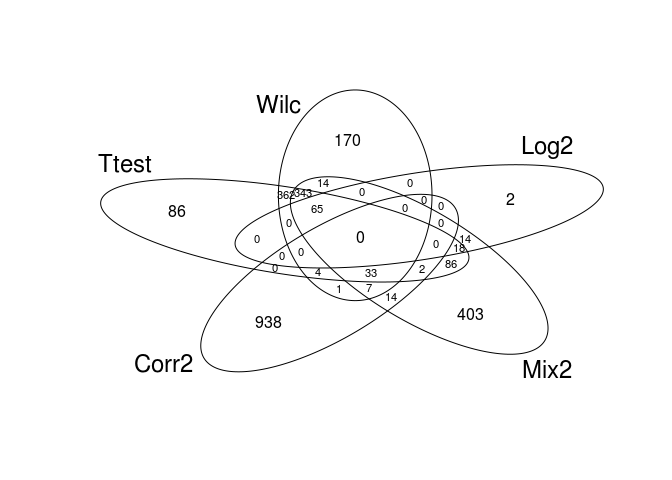

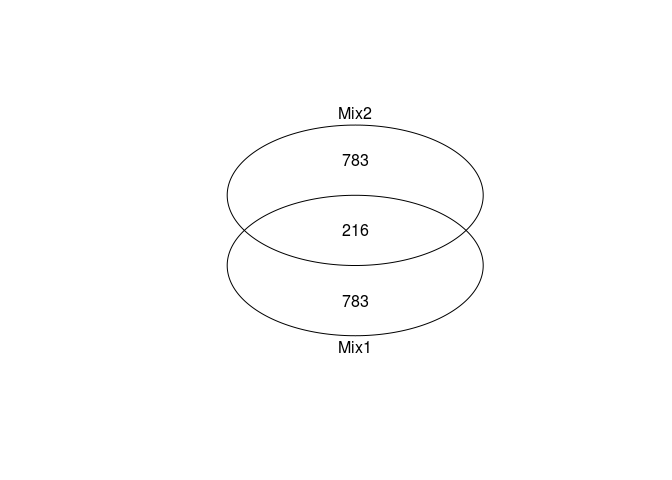

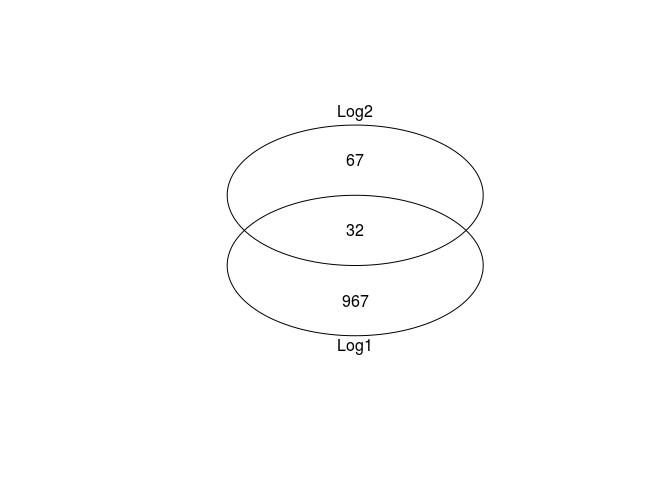

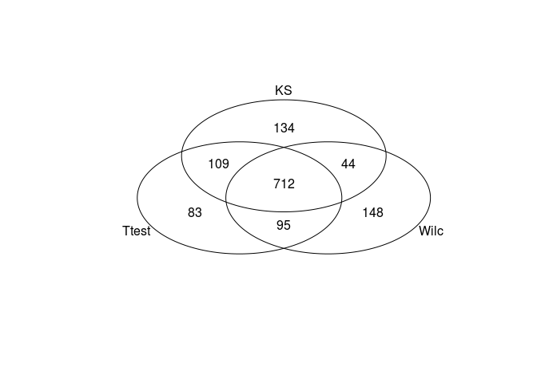

#### 3.3.7.1 Rozkłady top 1000 każdej z metod

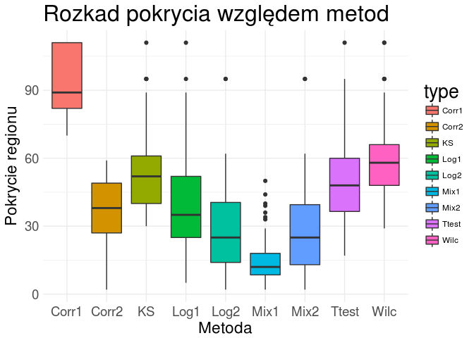

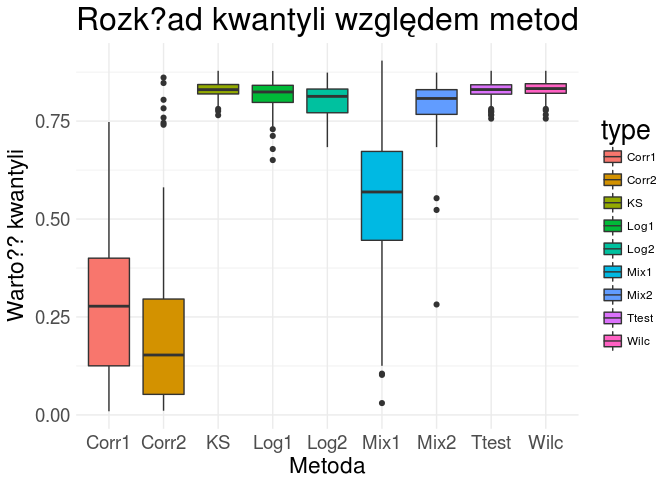